# Tutorial

- Introduction
  - Getting started
  - The concept of energy balance
  - A very simple microclimate model
- Above canopy
  - Radiation and albedo
  - Sensible heat and wind
    - Low wind speeds
    - The roughness sublayer
  - Latent heat and stomatal conductance
  - A more complex microclimate model
- Below canopy
  - Two-stream radiation models
  - Longwave radiation
  - Wind speed
  - Thermal diffusivity
  - Leaf temperature
  - Air temperature and humidity
    - The far field
    - The near field
    - Coupling leaves and air
- Ground heat storage
  - Simple estimates
  - Soil temperature model
  - Soil water model
- Snow
  - Snow energy balance
  - Snow mass balance
  - Snow model
  - Canopy snow interception
- Animal energy budgets
  - Radiation absorption
  - Resistance to heat loss
  - Metabolic rates
  - Ectotherms
  - Endotherms
    - Maintaining constant body temperature
    - How hot or cold the surroundings feel
- Microclimate models
  - micropoint
  - microclimf
  - mesoclim
  - microclimdata and mcera5
  - NicheMapR
  - TrenchR
- References

## Introduction

This vignette provides an introduction to mechanistic (process-based) microclimate modelling, with the basic concepts covered in progressively greater detail as you work through it. The package includes a set of R functions for calculating different components of microclimate, each of which is described in turn. At times, it may be useful to inspect the R code inside these functions, which can be done simply by typing the function name into the console. The functions are also extensively commented in the source code so you may wish also to inspect the functions on GitHub (e.g. by browsing the repository or cloning it locally), as comments are not shown when printing functions in R.

Some components of microclimate are tightly coupled. For example, surface temperature depends on the sensible heat flux, while the sensible heat flux itself depends on surface temperature. Resolving these feedbacks typically requires iteration, which can become slow when applied across long time series.

The vignette concludes with a section introducing a set of microclimate modelling packages aimed at ecologists, including micropoint, microclimf, and NicheMapR, and outlining what each is designed to do (and not do). All three rely on underlying compiled code (C++ or Fortran) to run these calculations efficiently. micropoint is particularly closely aligned with microclimlearn, mirroring its structure and calculations but implemented in C++ for improved performance. microclimf is designed for applying similar methods across landscapes to generate gridded outputs. NicheMapR, by contrast, is a point-based biophysical modelling framework built around a Fortran core, linking microclimate to organism heat and water balance, but it does not explicitly resolve below-canopy microclimate in the way the approaches developed here are intended to.

### Getting started

Install both packages from GitHub and load them as follows:

```r
require(devtools) # Install from CRAN if not already installed
devtools::install_github("ilyamaclean/microclimlearn")
devtools::install_github("ilyamaclean/micropoint")
library(microclimlearn)
```

### The concept of energy balance

The conceptual starting point for modelling microclimate is the law of energy conservation. Organisms and other opaque objects absorb shortwave solar radiation and longwave (thermal) radiation from the sky and surrounding surfaces, while emitting their own thermal radiation. They exchange sensible heat with the air and latent heat through vapour exchange (e.g. evapotranspirative cooling). When the net energy balance is positive, the object warms; when negative, it cools.

For small objects such as plant leaves, and over short periods (e.g. an hour), heat storage is negligible and fluxes reach a steady state. For larger objects, however, heat storage must be included to account for gains and losses through time. The same applies when modelling environmental temperatures, where heat storage by the ground is significant. Rather than treating temperature as a fully transient process, it is often more practical to include a term for the rate of heat storage or release. Within this framework, the temperature of a vegetated surface is that which balances the energy budget: when net radiation is positive, the surface warms, increasing sensible and latent heat losses until equilibrium is reached.

When modelling the microclimate of an environment, the surface undergoing energy exchange is generally represented by a single, homogeneous layer of vegetation. The energy balance of this surface layer is then solved to determine the equilibrium surface temperature, which in turn influences the temperature of the air above or within the canopy. The relevant inputs to an environmental microclimate model are macroclimate variables and a set of parameters describing the physical and radiative properties of the surface. For modelling the energy budget of an organism, the inputs instead comprise the local microclimate surrounding the organism and parameters describing its geometry, optical traits, and thermal properties. In both cases, the same physical principles apply.

In reality, vegetation is seldom homogeneous. Leaf area, canopy height, and optical properties vary both vertically and horizontally, creating spatial gradients in light, humidity, and temperature. These complexities are addressed in more detail below, where we extend the framework to describe energy exchange and microclimate variation beneath the canopy.

In the next section we illustrate how the energy balance can be solved by creating our own very simple microclimate model from first principles.

### A very simple microclimate model

The main function used in this example is SolveEnergyBalance, which forms the core of the simple microclimate model. We apply it to the built-in climate dataset provided with the package, but first we need to calculate several input variables. The most important of these is Rabs, the flux density of radiation absorbed by the canopy. This represents the sum of absorbed shortwave and longwave radiation.

To calculate absorbed shortwave radiation, we must specify an albedo — the fraction of incoming solar radiation that is reflected by the surface and therefore not absorbed. In the example below, albedo is held constant at 0.23. For longwave radiation, we specify an emissivity, which in this context can be interpreted as an absorption coefficient; this term is defined more precisely later in the vignette. We specify a value of 0.97, which is typical of vegetation. Conventionally emissivity is specified rather than reflectance as for longwave radiation it is also a measure of how efficiently radiation is emitted relative to an ideal black body. We return to this later.

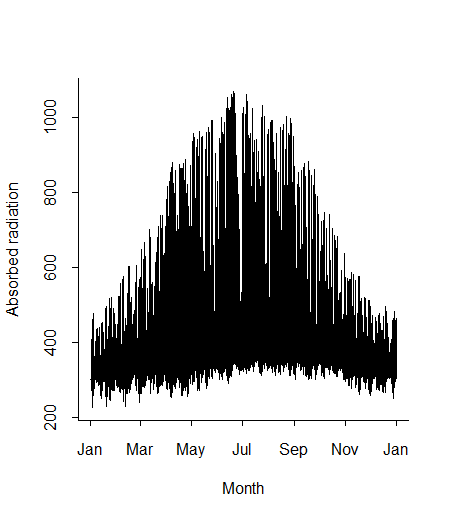

```r
# Calculate absorbed radiation
alb <- 0.23 # albedo
em <- 0.97  # emissivity
Rabs_sw <- (1 - alb) * climdata$swdown
Rabs_lw <- em * climdata$lwdown
Rabs <- Rabs_sw + Rabs_lw

# Plot through time
tme <- as.POSIXct(climdata$obs_time, tz = "UTC")
plot(Rabs ~ tme, type = "l",
     xlab = "Month",
     ylab = expression("Absorbed radiation (W " * m^-2 * ")"))
```

The next input we need to calculate is the bulk surface aerodynamic resistance to heat loss, a coefficient that determines how readily heat is transferred from the surface to the air. It decreases with increasing wind speed but also depends on the shape of the vertical wind-speed profile. To describe this profile, we must first calculate two key parameters: the zero-plane displacement height (the height above the ground at which wind flow effectively interacts with a vegetation canopy) and the roughness length for momentum, a surface property that controls how wind velocity changes with height. In addition, we calculate the roughness length for heat, which is related to the momentum roughness but specifically governs heat transfer. These terms are explained in more detail in the Sensible Heat section below; in essence, the first two describe the wind profile’s shape, while the third determines how efficiently heat is lost from the surface. All three tend to show a very consistent relationship with vegetation height. Below we use a simplified approach. A more comprehensive treatment is detailed in the Sensible Heat section.

```r
# Calculate resistance to heat loss
zref <- 2        # height above ground of weather data (m)
veghgt <- 0.12   # vegetation height (m)
ka <- 0.41       # von Kármán constant
d <- 0.65 * veghgt  # zero-plane displacement height (m)
zm <- 0.1 * veghgt  # roughness length for momentum (m)
zh <- 0.2 * zm      # roughness length for heat (m)

u2 <- climdata$windspeed
u2[u2 < 0.5] <- 0.5 # minimum wind speed (m s-1)

rHa <- (log((zref - d) / zm) * log((zref - d) / zh)) /
       (ka^2 * u2)  # resistance to heat loss
```

One point to note is that the line of code that computes `rHa` makes the assumption that macroclimate data provided as an input is above canopy (it is not possible to compute the log of a negative value). Most weather stations are located 1-2m above ground so this assumption will be violated for forest vegetation. The issue is quite hard to deal with and involves making some assumptions about the nature of the surface in which a weather station is located and then computing the vertical profiles in temperature, humidity, pressure and wind to derive expected values at some desired height above canopy. For simplicity the tutorial package always assumes that macroclimate data used to drive the microclimate models are above canopy. The `micropoint` package, however, includes a specific function for dealing with this issue - see `micropoint::weatherhgt_adjust`. The function only requires that a data.frame of weather inputs is provided and the latitude and longitude and desired height are specified by the user, so it can be applied easily to other datasets.

This point aside, next, we calculate the bulk surface stomatal resistance, which is the inverse of the total stomatal conductance of all leaves in the canopy, scaled to the ground surface, and represents the overall restriction to vapour flux imposed by stomata, which control how plants transpire. Plant transpiration is a complex and adaptive phenomenon, governed by the interaction between physiological regulation and environmental drivers: stomata open and close in response to light, humidity, temperature, and soil moisture, balancing the need for carbon uptake with the risk of excessive water loss. As a result, canopy-scale transpiration reflects both the physical environment and the dynamic behaviour of plants in maintaining water balance. This is tackled in more detail in the Latent Heat section, but here we adopt a simplified approach, which assumes that our surface is not water-stressed and that the main control on stomatal resistance is the flux density of photosynthetically active radiation, which when low, is assumed to increase stomatal resistance thereby inhibiting water loss. The assumed relationship between the two, while not wholly implausible, is somewhat arbitrary.

```r
# Calculate bulk surface stomatal resistance (rS)
gsmax <- 0.33 # maximum stomatal conductance of leaves (mol/m^2/s)
rho <- 43 # approximate molar density of air (mol / m^3)
# About half of shortwave radiation is PAR, and a joule of PAR is 4.6 umol of photons
rPAR <- climdata$swdown * 0.5 * 4.6  # Flux density of PAR (umol/m^2/s)
# The surface conducts about three times as much as its leaves (Kelliher et al. 1995)
rS <- rho * (rPAR + 300) /  (gsmax * 3 * rPAR) # s/m
```

Finally, we need to calculate the rate of heat storage by the ground. In practice, this is one of the most difficult components of the energy balance to estimate accurately, so we use the simplified approach recommended by the Food and Agriculture Organization (FAO). In this method, ground heat flux is assumed to equal one-tenth of net radiation during the day and one-half of net radiation at night.

```r
sb <- 5.67e-8 # Stefan–Boltzmann constant W/m^2/K^4
Rem <- em * sb * (climdata$temp + 273.15) ^ 4 # Emitted radiation (approx) W/m^2
Rnet <- Rabs - Rem # Net radiation (W/m^2)
G <- ifelse(Rnet > 0, 0.1 * Rnet, 0.5 * Rnet) # Rate of ground heat storage (W / m^2)
```

We can now calculate the surface temperature that balances the energy budget using the function `SolveEnergyBalance`. This function offers two solution methods. The “uniroot” option solves the energy balance numerically, using R’s built-in `uniroot` function to find the temperature at which net energy flux is zero. It provides an exact numerical solution but can be slower because it repeatedly evaluates the full energy balance. The “Penman” option applies the Penman–Monteith equation, estimating the equilibrium temperature through a linearised approximation of the energy terms. It is faster but less precise, and under extreme conditions can lead to noticeable errors. Accuracy of the “Penman” method can be improved substantially by allowing a few iterations.

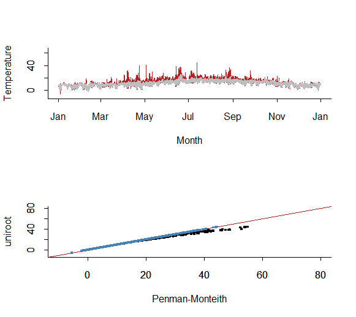

```r
# Find surface temperature using uniroot method
Ts1 <- SolveEnergyBalance(climdata$temp, climdata$pres, climdata$relhum,
                          Rabs, rHa, rS, G, em = 0.97,
                          method = "uniroot", iters = 1)
par(mfrow = c(2, 1))
plot(Ts1 ~ tme, type = "l", col = "firebrick",
     xlab = "Month", ylab = "Temperature", ylim = c(-10, 65))
par(new = TRUE)
plot(climdata$temp ~ tme, type = "l", lwd = 2, col = "gray",
     ylim = c(-10, 65), xlab = "", ylab = "")

# Compare with Penman-Monteith solution
Ts2 <- SolveEnergyBalance(climdata$temp, climdata$pres, climdata$relhum,
                          Rabs, rHa, rS, G, em = 0.97,
                          method = "Penman", iters = 1)
plot(Ts1 ~ Ts2, pch = 15, cex = 0.5,
     xlim = c(-10, 80), ylim = c(-10, 80),
     xlab = "Penman-Monteith", ylab = "uniroot")
abline(a = 0, b = 1, col = "firebrick")

# Improve Penman-Monteith solution by iterating
Ts2 <- SolveEnergyBalance(climdata$temp, climdata$pres, climdata$relhum,
                          Rabs, rHa, rS, G, em = 0.97,
                          method = "Penman", iters = 4)
par(new = TRUE)
plot(Ts1 ~ Ts2, pch = 15, cex = 0.5, col = "steelblue",
     xlim = c(-10, 80), ylim = c(-10, 80),
     xlab = "", ylab = "")
```

The temperature of this notional surface is mainly a theoretical construct, since real surfaces are rarely vertically uniform or isothermal. It represents an effective temperature at which the combined radiative, sensible, and latent heat fluxes balance. While not directly measurable, this quantity provides a useful physical reference and can be used to estimate near-surface air temperatures above vegetation, as shown below. Before doing that, we need to calculate a term called the wind friction velocity. We expand on this concept later.

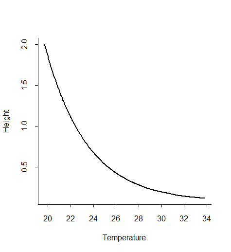

```r
# Calculate wind friction velocity
uf <- (ka * u2) / log((zref - d) / zm)

# Select hottest hour
hr <- which.max(Ts1)
Ts <- Ts1[hr]              # surface temperature
Ta <- climdata$temp[hr]    # air temperature

# Calculate sensible heat flux
pk <- climdata$pres[hr]
cp <- cpair(Ta)         # specific heat of air
ph <- rhoair(Ta, pk)   # molar density of air

H <- ((ph * cp) / rHa[hr]) * (Ts - Ta)

# Calculate temperature profile above canopy
z <- seq(0.12, 2, length.out = 100)
Tz <- Ts - (H / (ka * ph * cp * uf[hr])) * log((z - d) / zh)

par(mfrow = c(1, 1))
plot(z ~ Tz, type = "l", lwd = 2,
     xlab = "Temperature", ylab = "Height")
```

We now describe the radiation, sensible and latent heat components of the energy budget in more detail, beginning with the simpler case of deriving microclimate conditions above the canopy, before turning to the more complex situation below the canopy. We then turn to modelling ground heat flux, which itself requires modelling of soil water content.

## Above canopy

### Radiation and albedo

In the simple example above, albedo — the fraction of shortwave radiation reflected rather than absorbed — was held constant. In reality, it varies with both ground reflectance and the reflectance of any overlying vegetation. Their relative contributions depend on how much radiation reaches the ground, which for the direct beam is determined by leaf inclination and the solar zenith angle: vertically oriented leaves intercept more sunlight when the sun is low in the sky. To account for this, we first need to calculate the solar zenith angle. The sunposition function does this from a POSIXlt time vector and a single latitude–longitude pair. It returns both the zenith angle (0 at the sun’s zenith, 90 at the horizon) and the azimuth (0 = north, 90 = east). Times must be in UTC.

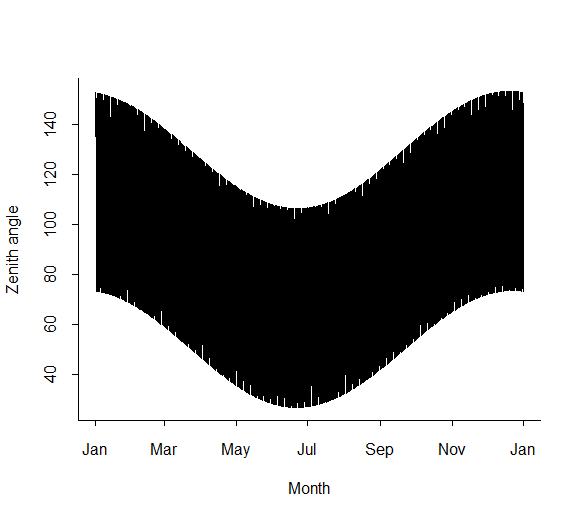

```r
tme <- as.POSIXlt(climdata$obs_time, tz = "UTC")
solp <- sunposition(tme, lat = 49.96807, long = -5.215668)

plot(solp$zen ~ as.POSIXct(tme), type = "l",
     xlab = "Month", ylab = "Zenith angle")
```

The reader may wish to use the `sunposition` function to explore how the solar zenith angle changes over the course of a single day or with latitude.

The `albedo` function handles albedo calculations, but before demonstrating it, we briefly turn to how direct radiation is attenuated through a vegetated canopy. Because this depends on leaf inclination, which is impractical to specify for individual leaves, we assume a continuous distribution of leaf angles following an oblate or prolate spherical form. This is reasonable for many canopies but may be less appropriate for species with strongly heliotropic leaves or highly directional foliage arrangements. The distribution is defined by a single parameter x, representing the ratio of horizontal to vertical leaf projections (x = 0 for completely vertical leaves, x = infinity for completely horizontal leaves, and x = 1 for random orientation).

We also account for the possibility of sloping ground, which alters the optical path length through the canopy. This is handled by computing a solar coefficient that expresses the fraction of direct radiation intercepted by a surface relative to one perpendicular to the solar beam. Terrain shading could additionally be incorporated by setting direct radiation to zero when the sun is below the local horizon. From this, we derive an extinction coefficient that determines how strongly the canopy attenuates direct beam radiation per unit plant area index (PAI):

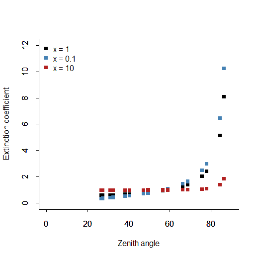

```r
# Select daylight hours on June 21
sel <- which(tme$mon + 1 == 6 & tme$mday == 21 & solp$zen < 90)
solp2 <- lapply(solp, `[`, sel)

# Compute solar coefficient for flat surface
si <- solarindex(slope = 0, aspect = 180, solp2)

# Compute extinction coefficient
k1 <- cank(solp2, x = 1, si)
k2 <- cank(solp2, x = 0.1, si)
k3 <- cank(solp2, x = 10, si)

# Plot extinction coefficient
plot(k1 ~ solp2$zen, pch = 15, col = "black",
     xlim = c(0, 90), ylim = c(0, 12),
     xlab = "Zenith angle", ylab = "Extinction coefficient")
par(new = TRUE)
plot(k2 ~ solp2$zen, pch = 15, col = "steelblue",
     xlim = c(0, 90), ylim = c(0, 12),
     xlab = "", ylab = "")
par(new = TRUE)
plot(k3 ~ solp2$zen, pch = 15, col = "firebrick",
     xlim = c(0, 90), ylim = c(0, 12),
     xlab = "", ylab = "")

legend("topleft", legend = c("x = 1", "x = 0.1", "x = 10"),
       col = c("black", "steelblue", "firebrick"), pch = 15, bty = "n")
```

You can see here how leaf inclination affects the extinction coefficient: more vertically oriented leaves reduce attenuation when the sun is near its zenith but greatly increase it when the sun is low (high zenith angles). The `albedo` function calls `cank` so there is no need to compute the extinction coefficient separately. It requires several inputs as detailed in the comments below. Here typical values are chosen. The `scattermethod` input just determines which method to use to calculate the radiation scattering directionality factor (see `?scattercoef`). The Sellers method specified by default is marginally less accurate than the computationally more complex Pinty method. The `leafh` input is logical, indicating whether the plant area index is per unit horizontal ground area (`TRUE`) or per unit inclined ground area (`FALSE`).

```r
pai <- 3      # plant area index (m^2 m^-2)
lref <- 0.4   # leaf reflectance
ltra <- 0.2   # leaf transmittance
x <- 1        # leaf inclination coefficient
gref <- 0.15  # ground reflectance
slope <- 30   # ground slope (degrees)
aspect <- 180 # ground aspect (degrees)

# Compute albedo variables
albvars <- albedo(pai, lref, ltra, x, gref, slope, aspect, solp,
                  scattermethod = "Sellers", leafh = FALSE)
```

The function returns albd, the white-sky albedo for diffuse radiation (independent of solar zenith angle and therefore time-invariant); albb, the black-sky albedo for direct radiation (time-varying); and trd, the fraction of diffuse radiation that passes through the canopy to the ground. To obtain the overall albedo, combine the white- and black-sky components by weighting them according to the fraction of the radiation arriving at the surface that is diffuse, which on sloping ground means first working out how much direct radiation the slope receives:

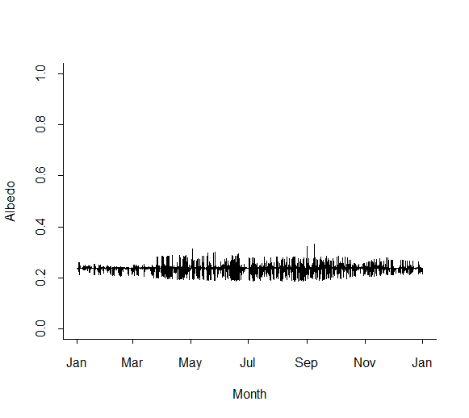

```r
# Direct radiation on a surface facing the sun, from that on flat ground
Rb0 <- (climdata$swdown - climdata$difrad) / cos(solp$zen * pi / 180)

# Direct radiation arriving at the sloping surface
si <- solarindex(slope, aspect, solp)
Rdir <- Rb0 * si

# Fraction of the radiation arriving at the slope that is diffuse
Rtot <- climdata$difrad + Rdir
difprop <- climdata$difrad / Rtot
difprop[Rtot == 0] <- 1

# Calculate albedo
alb <- difprop * albvars$albd + (1 - difprop) * albvars$albb

plot(alb ~ as.POSIXct(tme), type = "l", ylim = c(0, 1),
     xlab = "Month", ylab = "Albedo")
```

Sun-facing slopes absorb more direct radiation than flat ground. The `calcRabs` function brings everything together to estimate the total radiation absorbed by the vegetation and the underlying ground surface, including both shortwave and longwave components.

Because `calcRabs` and related functions require multiple vegetation and ground parameters, these are grouped into single lists, as shown below. Parameter names follow the same convention as in the micropoint package.

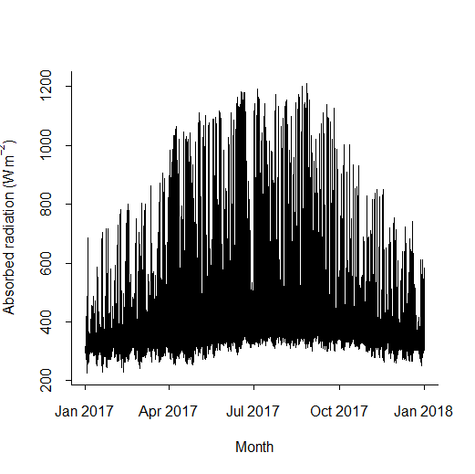

```r
# Create list of vegetation parameters
vegvars <- list(h = 0.12,    # vegetation height (m)
                pai = 1,     # plant area index
                x = 1,       # leaf inclination coefficient
                lref = 0.4,  # vegetation reflectance
                ltra = 0.2,  # vegetation transmittance
                em = 0.97)   # vegetation emissivity

# Create list of ground parameters
groundvars <- list(gref = 0.15, # ground reflectance
                   slope = 30,  # slope (degrees)
                   aspect = 180,# aspect (degrees)
                   em = 0.95)   # ground emissivity

# Calculate absorbed radiation
Rabs <- calcRabs(climdata, vegvars, groundvars,
                 lat = 49.96807, long = -5.215668)

# Plot absorbed radiation through time
plot(Rabs ~ as.POSIXct(tme), type = "l",
     xlab = "Month",
     ylab = expression("Absorbed radiation (W " * m^-2 * ")"))
```

### Sensible heat and wind

The sensible heat flux from a vegetated surface depends on the temperature difference between the surface and the air at a reference height above the canopy, and on how easily moving air can carry that heat away (the convective conductivity, or the inverse of resistance to heat loss). Stronger winds reduce this resistance and allow more heat to be transferred. Because wind speed changes with height — slower near the surface and faster higher up — estimating this resistance requires describing how wind varies vertically. The key quantity that controls this wind-speed profile is the friction velocity, which is simply a measure of how strongly the wind interacts with and “drags” against the surface. In plain terms, it captures how vigorously the wind is stirring the air close to the ground: higher friction velocity means more turbulence and more efficient heat exchange.

The relationship between wind speed at reference height and friction velocity is set by two additional parameters: the roughness length for momentum, which reflects how rough the canopy surface is to the wind, and the zero-plane displacement height, which controls the height above the ground surface at which the wind profile extrapolates to zero. Together, these describe how vegetation slows and redirects airflow, shaping the wind profile near the surface. In the simple example above these parameters were calculated from vegetation height, but in reality they have an additional dependence on the plant area index. The `windfric` function calculates them automatically, but thus requires `pai` to be passed as an input.

In the code below, we first define the wind speed at the reference height, the three canopy heights, and plant area index. We then compute the friction velocity. Next, we create height vectors spanning from the top of each canopy to `zref`, apply the wind-profile function to each, and plot the resulting profiles, with dashed lines marking canopy height.

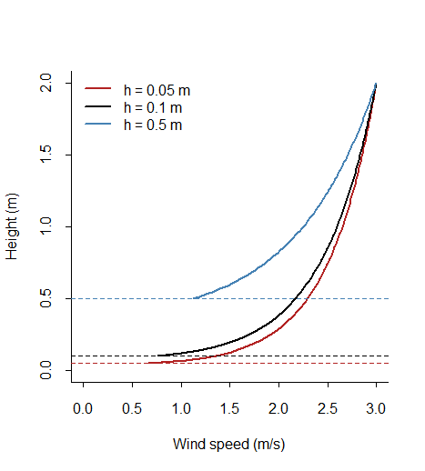

```r
# Plot wind profiles for three canopy heights
uref <- 3            # wind speed at reference height (m s-1)
zref <- 2            # reference height (m)
h <- c(0.05, 0.1, 0.5) # vegetation heights (m)
pai <- 1             # plant area index

uf <- windfric(uref, zref, h, pai)  # friction velocity

# Build height grids and wind profiles
z_list <- lapply(h, function(hi) seq(hi, zref, length.out = 100))
uz_list <- Map(function(z, ufi, hi)
                 windprofile_above(z, ufi, hi, pai),
               z_list, as.list(uf), as.list(h))

# Bind to matrices for plotting
Z <- do.call(cbind, z_list)
UZ <- do.call(cbind, uz_list)

# Plot wind profiles
cols <- c("firebrick", "black", "steelblue")

matplot(UZ, Z, type = "l", lwd = 2, col = cols, lty = 1,
        xlab = "Wind speed (m s-1)",
        ylab = "Height (m)",
        xlim = c(0, 3), ylim = c(0, 2))

abline(h = h, lty = 2, col = cols)

legend("topleft",
       legend = c("h = 0.05 m", "h = 0.1 m", "h = 0.5 m"),
       col = cols, lwd = 2, bty = "n")
```

A further complication is that friction velocity and resistance to heat loss both depend on thermally generated turbulence, quantified using diabatic corrections for momentum and heat. These corrections require that the sensible heat flux is known, yet estimating that flux also depends on diabatic coefficients, creating a circular problem that must be solved iteratively. I.e. when a surface is heated, the air above it becomes more turbulent and it loses heat more readily, and when it is cooled, the opposite occurs, but in both instances the degree of heating and cooling depends on how much turbulence there is. The `micropoint` package handles this iterative process automatically. The wind profiles above ignore the diabatic corrections, and in the example below we show how vegetation height influences the shape of the temperature profile in the same way. This is the default behaviour of the functions, which assume neutral conditions unless told otherwise. Below that we show how the diabatic corrections can be derived iteratively and influence the shape of the profiles.

In the code below we set the air temperature and pressure at the reference height, assume a sensible heat flux of 200 W per square metre, and calculate the volumetric heat capacity of air. We then compute the resistance to zref for each canopy and use this to estimate its heat-exchange surface temperature. Next, we obtain resistances for each height vector and, together with the surface temperatures, derive temperature–height profiles, which are then plotted.

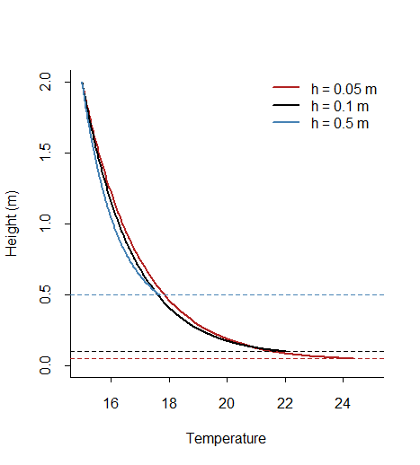

```r
# Plot temperature profiles for three canopy heights
tref <- 15        # air temperature at reference height (°C)
pk <- 101.3       # pressure (kPa)
H <- 200          # sensible heat flux (W m^-2)

phcp <- rhoair(tref, pk) * cpair(tref) # volumetric heat capacity of air

# Resistance to reference height for each canopy
rHa_ref <- canopyresistance(zref, uf, h, pai)

# Heat-exchange surface temperature
th <- tref + (rHa_ref / phcp) * H

# Resistance and temperature profiles
rHa_z_list <- Map(function(z, ufi, hi)
                    canopyresistance(z, ufi, hi, pai),
                  z_list, as.list(uf), as.list(h))

tz_list <- Map(function(rHa_i, th_i)
                 th_i - (rHa_i / phcp) * H,
               rHa_z_list, as.list(th))

# Bind for plotting
TZ <- do.call(cbind, tz_list)
Z <- do.call(cbind, z_list)

# Plot profiles
matplot(TZ, Z, type = "l", lwd = 2, col = cols, lty = 1,
        xlab = expression("Temperature (" * degree * "C)"),
        ylab = "Height (m)",
        xlim = c(15, 25), ylim = c(0, 2))

abline(h = h, lty = 2, col = cols)

legend("topright",
       legend = paste("h =", h, "m"),
       col = cols, lwd = 2, lty = 1, bty = "n")
```

In the examples below, we show how the diabatic coefficients are derived iteratively and demonstrate their influence on the temperature and wind profiles. In contrast to the previous examples, we set the radiation absorbed by the canopy (`Rabs`) and then calculate the sensible heat flux explicitly. In the first example we set a high value for `Rabs` to ensure surface heating. Neutral conditions are assumed initially, so the wind and temperature profiles are calculated as before, except that the sensible heat flux is now obtained from the heat-exchange surface temperature using `SolveEnergyBalance`, rather than specified directly. The degree to which heating or cooling of the surface alters turbulence is described by a quantity called the Obukhov length, which is simply a measure of the height above the surface where buoyancy begins to meaningfully influence turbulence. It is calculated from the friction velocity and the sensible heat flux, and is passed to the functions as the input `LL`, from which they calculate the diabatic corrections internally. We therefore calculate the Obukhov length from the neutral solution and then use a `while` loop to update it iteratively, repeating the calculations until the friction velocity converges.

```r
# -------------------------------------------------------------- #
# ************  Heated surface example ************************* #
# -------------------------------------------------------------- #

Rabs <- 1000 # absorbed radiation (W m^-2); high value heats canopy
z <- seq(0.12, 2, length.out = 100) # heights above a 0.12 m canopy (m)

# * * Compute wind profile assuming neutral atmospheric conditions * * #
uf <- windfric(uref = 3, zref = 2, h = 0.12, pai = 1) # friction velocity
uz1 <- windprofile_above(z, uf, h = 0.12, pai = 1)

# * * Compute temperature profile assuming neutral conditions * * #
rHa <- canopyresistance(z = 2, uf, h = 0.12, pai = 1) # aerodynamic resistance
th <- SolveEnergyBalance(Ta = 15, pk = 101.3, rh = 75, Rabs, rHa, rS = 100,
                         G = 0, em = 0.97,
                         method = "uniroot") # canopy temperature
phcp <- rhoair(15, 101.3) * cpair(15) # volumetric heat capacity of air
H <- (phcp / rHa) * (th - 15) # sensible heat flux
rHa <- canopyresistance(z, uf, h = 0.12, pai = 1) # resistance at each height
tz1 <- th - (rHa / phcp) * H # air temperature profile

# * * * * * Iterate to derive the Obukhov length * * * * * #
LL <- Obukhov(15, 101.3, uf, H) # Obukhov length from the neutral solution
tol <- 1e-9 # convergence tolerance
error <- tol * 100

while (error > tol) {
  olduf <- uf
  uf <- windfric(uref = 3, zref = 2, h = 0.12, pai = 1, LL) # update friction velocity
  rHa <- canopyresistance(z = 2, uf, h = 0.12, pai = 1, LL) # update aerodynamic resistance

  th <- SolveEnergyBalance(Ta = 15, pk = 101.3, rh = 75, Rabs, rHa,
                           rS = 100, G = 0, em = 0.97,
                           method = "uniroot") # updated canopy temperature

  H <- (phcp / rHa) * (th - 15) # updated sensible heat flux
  LL <- Obukhov(15, 101.3, uf, H) # updated Obukhov length

  error <- abs(uf - olduf)
}

# * * Recalculate profiles including diabatic corrections * * #
uz2 <- windprofile_above(z, uf, h = 0.12, pai = 1, LL) # wind profile with stability corrections
rHa <- canopyresistance(z, uf, h = 0.12, pai = 1, LL) # resistance at each height
tz2 <- th - (rHa / phcp) * H # temperature profile with stability corrections
```

In the following example we adopt exactly the same procedure, but here `Rabs` is set to a low value to simulate surface cooling.

```r
# -------------------------------------------------------------- #
# ************  Cooled surface example ************************* #
# -------------------------------------------------------------- #

Rabs <- 250 # absorbed radiation (W m^-2); low value cools canopy
z <- seq(0.12, 2, length.out = 100) # heights above a 0.12 m canopy (m)

# * * Compute temperature profile assuming neutral conditions * * #
uf <- windfric(uref = 3, zref = 2, h = 0.12, pai = 1) # friction velocity
rHa <- canopyresistance(z = 2, uf, h = 0.12, pai = 1) # aerodynamic resistance
th <- SolveEnergyBalance(Ta = 15, pk = 101.3, rh = 75, Rabs, rHa, rS = 100,
                         G = 0, em = 0.97,
                         method = "uniroot") # canopy temperature

phcp <- rhoair(15, 101.3) * cpair(15) # volumetric heat capacity of air
H <- (phcp / rHa) * (th - 15) # sensible heat flux

rHa <- canopyresistance(z, uf, h = 0.12, pai = 1) # resistance at each height
uz3 <- uz1 # the neutral wind profile is the same as for the heated surface
tz3 <- th - (rHa / phcp) * H # air temperature profile

# * * * * * Iterate to derive the Obukhov length * * * * * #
LL <- Obukhov(15, 101.3, uf, H) # Obukhov length from the neutral solution
tol <- 1e-9 # convergence tolerance
error <- tol * 100

while (error > tol) {
  olduf <- uf
  uf <- windfric(uref = 3, zref = 2, h = 0.12, pai = 1, LL) # update friction velocity
  rHa <- canopyresistance(z = 2, uf, h = 0.12, pai = 1, LL) # update aerodynamic resistance

  th <- SolveEnergyBalance(Ta = 15, pk = 101.3, rh = 75, Rabs, rHa,
                           rS = 100, G = 0, em = 0.97,
                           method = "uniroot") # updated canopy temperature

  H <- (phcp / rHa) * (th - 15) # updated sensible heat flux
  LL <- Obukhov(15, 101.3, uf, H) # updated Obukhov length

  error <- abs(uf - olduf)
}

# * * Recalculate temperature and wind profile * * #
uz4 <- windprofile_above(z, uf, h = 0.12, pai = 1, LL) # wind profile with stability corrections
rHa <- canopyresistance(z, uf, h = 0.12, pai = 1, LL) # resistance at each height
tz4 <- th - (rHa / phcp) * H # temperature profile with stability corrections
```

In the code below, we plot the wind and temperature profiles to illustrate the influence of the diabatic coefficients.

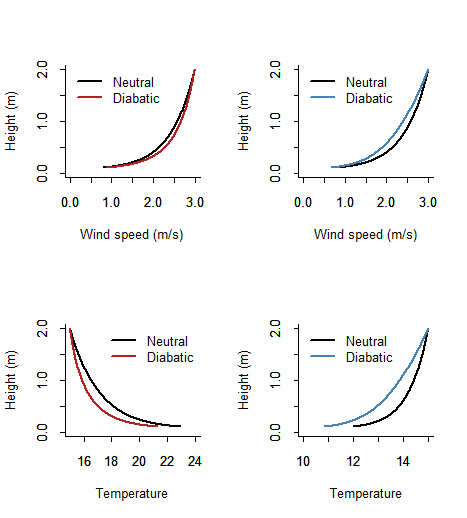

```r
# -------------------------------------------------------------- #
# ************  Plot both sets of profiles  ******************** #
# -------------------------------------------------------------- #

# Compare wind profiles
plot(z ~ uz1, type = "l", lwd = 2,
     xlim = c(0, 3), ylim = c(0, 2),
     xlab = expression("Wind speed (m s"^-1 * ")"),
     ylab = "Height (m)")

par(new = TRUE)
plot(z ~ uz2, type = "l", lwd = 2, col = "firebrick",
     xlim = c(0, 3), ylim = c(0, 2),
     xlab = "", ylab = "")

legend("topleft", legend = c("Neutral", "Diabatic"),
       col = c("black", "firebrick"), lwd = 2, bty = "n")

plot(z ~ uz3, type = "l", lwd = 2,
     xlim = c(0, 3), ylim = c(0, 2),
     xlab = expression("Wind speed (m s"^-1 * ")"),
     ylab = "Height (m)")

par(new = TRUE)
plot(z ~ uz4, type = "l", lwd = 2, col = "steelblue",
     xlim = c(0, 3), ylim = c(0, 2),
     xlab = "", ylab = "")

legend("topleft", legend = c("Neutral", "Diabatic"),
       col = c("black", "steelblue"), lwd = 2, bty = "n")

# Compare temperature profiles
plot(z ~ tz1, type = "l", lwd = 2,
     xlim = c(15, 24), ylim = c(0, 2),
     xlab = expression("Temperature (" * degree * "C)"),
     ylab = "Height (m)")

par(new = TRUE)
plot(z ~ tz2, type = "l", lwd = 2, col = "firebrick",
     xlim = c(15, 24), ylim = c(0, 2),
     xlab = "", ylab = "")

legend("topright", legend = c("Neutral", "Diabatic"),
       col = c("black", "firebrick"), lwd = 2, bty = "n")

plot(z ~ tz3, type = "l", lwd = 2,
     xlim = c(10, 15), ylim = c(0, 2),
     xlab = expression("Temperature (" * degree * "C)"),
     ylab = "Height (m)")

par(new = TRUE)
plot(z ~ tz4, type = "l", lwd = 2, col = "steelblue",
     xlim = c(10, 15), ylim = c(0, 2),
     xlab = "", ylab = "")

legend("topleft", legend = c("Neutral", "Diabatic"),
       col = c("black", "steelblue"), lwd = 2, bty = "n")
```

When the surface is heated, buoyancy adds to turbulence, producing a slight increase in friction velocity (`uf`). The air is mixed more thoroughly, so wind speed is more uniform with height than under neutral conditions and is higher close to the canopy. When the surface is cooled, buoyancy suppresses turbulence, reducing `uf`, and wind speed close to the canopy is lower and increases more steadily with height. The temperature profiles behave similarly: under heating, resistance to heat loss is reduced, lowering canopy-top temperatures relative to the neutral case and confining the steepest part of the temperature gradient to the air just above the canopy. Under cooling, resistance to heat loss increases, so the canopy and the air close to it are colder than in the neutral case and the temperature difference extends further up the profile.

#### Low wind speeds

The calculations above run into difficulty when there is very little wind. As wind speed approaches zero, friction velocity and turbulent heat exchange also decline, causing resistance to heat loss to become very large. Sun-heated surfaces then attain unrealistically high modelled temperatures. In reality, a hot surface generates its own air movement: the air warmed by the surface rises and draws in cooler air. This process, known as free convection, maintains heat exchange even in still conditions.

The function `effectivewind` accounts for free convection by estimating the velocity of the rising air from the sensible heat flux and combining it with the measured wind speed. This effective wind speed replaces the measured wind speed when calculating friction velocity. When heat flows from the air to the surface, free convection does not occur and the measured wind speed is used unchanged. Because the calculation depends on sensible heat flux, effective wind speed is updated iteratively alongside the Obukhov length.

The code below calculates the temperature of a strongly heated canopy across a range of wind speeds, using the same approach as the heated surface example above. We compare results with and without free convection and plot the differences.

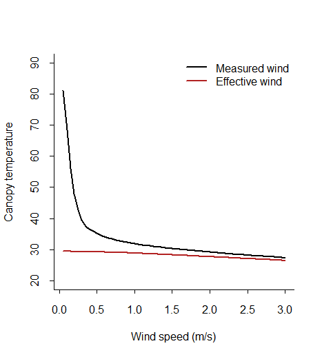

```r
# Canopy temperature of a strongly heated surface at a given wind speed
canopytemp <- function(uref, convection) {
  phcp <- rhoair(15, 101.3) * cpair(15) # volumetric heat capacity of air
  H <- 0     # sensible heat flux, none initially
  LL <- Inf  # neutral conditions initially
  uf <- 0
  error <- 1

  while (error > 1e-9) {
    olduf <- uf
    u <- uref
    # Add the stirring of the air by convection to the measured wind
    if (convection) u <- effectivewind(uref, H, tc = 15, pk = 101.3)

    uf <- windfric(u, zref = 2, h = 0.12, pai = 1, LL) # friction velocity
    rHa <- canopyresistance(z = 2, uf, h = 0.12, pai = 1, LL) # aerodynamic resistance

    th <- SolveEnergyBalance(Ta = 15, pk = 101.3, rh = 75, Rabs = 1000, rHa,
                             rS = 100, G = 0, em = 0.97,
                             method = "Penman", iters = 5) # canopy temperature

    H <- (phcp / rHa) * (th - 15) # sensible heat flux
    LL <- Obukhov(15, 101.3, uf, H) # Obukhov length

    error <- abs(uf - olduf)
  }
  return(th)
}

# Canopy temperature across a range of wind speeds
uref <- seq(0.05, 3, length.out = 60) # wind speed at reference height (m/s)
th1 <- sapply(uref, canopytemp, convection = FALSE) # measured wind only
th2 <- sapply(uref, canopytemp, convection = TRUE)  # with convection

plot(th1 ~ uref, type = "l", lwd = 2, ylim = c(20, 90),
     xlab = "Wind speed (m/s)", ylab = "Canopy temperature")
lines(th2 ~ uref, lwd = 2, col = "firebrick")

legend("topright", legend = c("Measured wind", "Effective wind"),
       col = c("black", "firebrick"), lwd = 2, bty = "n")
```

Using measured wind speed alone, canopy temperature rises steeply as the wind drops and exceeds 80 °C in near-calm conditions. With the effective wind speed, canopy temperature levels off at about 29 °C, because the convection generated by the surface itself is then sufficient to carry the heat away. At higher wind speeds convection adds less to the measured wind and the two estimates converge, differing by about 1 °C at 3 m/s.

#### The roughness sublayer

So far, we have calculated how wind speed and temperature vary with height using a standard approach known as Monin-Obukhov Similarity Theory (MOST). This describes how turbulent mixing changes with height above the ground, accounting for both wind and the effects of atmospheric stability. A key assumption is that the turbulent eddies responsible for mixing become progressively larger with height. However, this assumption breaks down just above vegetation, particularly forests. Where faster-moving air above the canopy meets slower-moving air within it, large eddies form that enhance mixing. The region influenced by these eddies is known as the roughness sublayer. It extends only a short distance above low vegetation, but can reach several metres above a forest canopy.

The functions `windfric`, `windprofile_above` and `canopyresistance` use MOST by default (`MOST = TRUE`), as in the examples above. Setting `MOST = FALSE` also accounts for the enhanced mixing within the roughness sublayer. Below, we calculate wind profiles above a 10 m forest canopy under neutral atmospheric conditions, with and without this adjustment. We then plot the results, marking the top of the roughness sublayer with a dashed line.

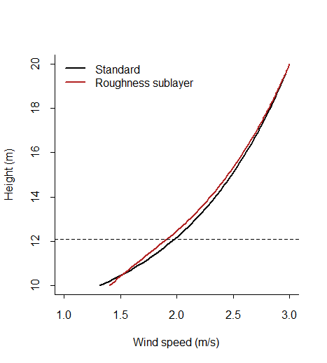

```r
# Wind profile above a forest canopy with and without a roughness sublayer
uref <- 3   # wind speed at reference height (m/s)
zref <- 20  # reference height (m)
h <- 10     # vegetation height (m)
pai <- 3    # plant area index

z <- seq(h, zref, length.out = 100) # heights above canopy (m)

# Standard profile
uf1 <- windfric(uref, zref, h, pai) # friction velocity
uz1 <- windprofile_above(z, uf1, h, pai)

# Profile with a roughness sublayer
uf2 <- windfric(uref, zref, h, pai, MOST = FALSE) # friction velocity
uz2 <- windprofile_above(z, uf2, h, pai, MOST = FALSE)

# Height of the top of the roughness sublayer
d <- zeroplanedis(h, pai) # zero-plane displacement height
zw <- d + 2 * (h - d)

plot(z ~ uz1, type = "l", lwd = 2,
     xlim = c(1, 3), ylim = c(h, zref),
     xlab = "Wind speed (m/s)", ylab = "Height (m)")
lines(z ~ uz2, lwd = 2, col = "firebrick")
abline(h = zw, lty = 2)

legend("topleft", legend = c("Standard", "Roughness sublayer"),
       col = c("black", "firebrick"), lwd = 2, bty = "n")
```

Within the roughness sublayer the more effective mixing means that wind speed changes less steeply with height, so the wind at the canopy top is slightly stronger. Above the sublayer both profiles are logarithmic and converge on the wind speed at the reference height. The effects of the roughness sublayer on heat exchange are covered later.

### Latent heat and stomatal conductance

In our simple microclimate example, bulk surface stomatal resistance to vapour loss is calculated using a basic approach in which stomata respond only to photosynthetically active radiation. In reality, transpiration is a dynamic, regulated process: stomata respond to light, humidity, temperature, and soil moisture, balancing carbon uptake against the risk of excessive water loss. Capturing this behaviour requires a more detailed representation of stomatal resistance. The model presented below is an analytical stomatal-optimisation scheme developed as part of the xylem-hydraulics component of the Joint UK Land Environment Simulator (JULES) land-surface model (Eller et al. 2020).

This model is relatively parameter-rich, so a table of values for major plant functional types is included with the tutorial package. The helper function createplant_inputs() extracts the relevant values and returns a ready-to-use list of vegetation parameters for a chosen plant functional type. The available plant functional types (see ?PFTtable) are intentionally broad and are best treated as starting points for more detailed, site- or species-specific parameterisation. For example, a nominal vegetation height is provided, but users will often have better information for their target vegetation. Many of the remaining traits correspond to those available in the TRY database.

In the example below, we first extract vegetation parameters for C3 grass and then run the key function stomatalcond_calc. This returns stomatal conductance (the inverse of resistance), calculated at the leaf scale. Although the model is intended for individual leaves, it is useful to first explore how conductance responds to environmental drivers, so we illustrate this here.

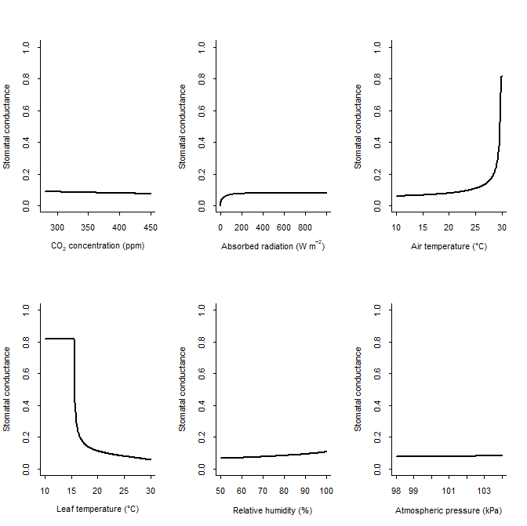

```r
# Create list of vegetation parameters
vegparams <- createplant_inputs("C3")

# Plot stomatal response to climate inputs
z <- vegparams$h / 2 # average canopy height

par(mfrow = c(2, 3))

# CO2 concentration
Ca <- 280:450 # CO2 concentration (ppm)

gs <- stomatalcond_calc(Ca, Rswabs = 500, tair = 20, tleaf = 25,
                        rh = 75, pk = 101.3, psi_r = -0.005,
                        vegparams, z, C3 = TRUE)

plot(gs ~ Ca, type = "l", lwd = 2,
     xlab = expression(CO[2] ~ "concentration (ppm)"),
     ylab = "Stomatal conductance",
     ylim = c(0, 1))

# Shortwave radiation
Rswabs <- 0:1000 # radiation absorbed by the leaf (W m^-2), of which 48% is taken to be PAR

gs <- stomatalcond_calc(Ca = 400, Rswabs, tair = 20, tleaf = 25,
                        rh = 75, pk = 101.3, psi_r = -0.005,
                        vegparams, z, C3 = TRUE)

plot(gs ~ Rswabs, type = "l", lwd = 2,
     xlab = expression("Absorbed radiation (W " * m^-2 * ")"),
     ylab = "Stomatal conductance",
     ylim = c(0, 1))

# Air temperature
tair <- (100:300) / 10 # air temperature (°C)

gs <- stomatalcond_calc(Ca = 400, Rswabs = 500, tair, tleaf = 25,
                        rh = 75, pk = 101.3, psi_r = -0.005,
                        vegparams, z, C3 = TRUE)

plot(gs ~ tair, type = "l", lwd = 2,
     xlab = expression("Air temperature (" * degree * "C)"),
     ylab = "Stomatal conductance",
     ylim = c(0, 1))

# Leaf temperature
tleaf <- (100:300) / 10 # leaf temperature (°C)

gs <- stomatalcond_calc(Ca = 400, Rswabs = 500, tair = 20, tleaf,
                        rh = 75, pk = 101.3, psi_r = -0.005,
                        vegparams, z, C3 = TRUE)

plot(gs ~ tleaf, type = "l", lwd = 2,
     xlab = expression("Leaf temperature (" * degree * "C)"),
     ylab = "Stomatal conductance",
     ylim = c(0, 1))

# Relative humidity
rh <- 50:100 # relative humidity (%)

gs <- stomatalcond_calc(Ca = 400, Rswabs = 500, tair = 20, tleaf = 25,
                        rh, pk = 101.3, psi_r = -0.005,
                        vegparams, z, C3 = TRUE)

plot(gs ~ rh, type = "l", lwd = 2,
     xlab = "Relative humidity (%)",
     ylab = "Stomatal conductance",
     ylim = c(0, 1))

# Atmospheric pressure
pk <- c(980:1040) / 10 # pressure (kPa)

gs <- stomatalcond_calc(Ca = 400, Rswabs = 500, tair = 20, tleaf = 25,
                        rh = 75, pk, psi_r = -0.005,
                        vegparams, z, C3 = TRUE)

plot(gs ~ pk, type = "l", lwd = 2,
     xlab = "Atmospheric pressure (kPa)",
     ylab = "Stomatal conductance",
     ylim = c(0, 1))
```

Stomatal conductance declines modestly with increasing CO2, as higher ambient concentrations allow the same rate of carbon assimilation with a smaller stomatal aperture. It rises steeply with radiation at low light levels, reflecting light limitation of photosynthesis, but soon saturates, changing little once the leaf absorbs more than about 100 W m<sup>-2</sup>. The temperature panels reflect both a direct effect of temperature on photosynthetic rates and a strong indirect effect through VPD: as the difference between leaf and air temperature changes, so does the vapour pressure deficit, altering the hydraulic cost of transpiration. Where the prescribed combination of leaf and air temperature drives VPD towards zero, stomatal conductance rises sharply to its anatomical maximum, and it remains there when the leaf is at or below the dewpoint of the air, as there is then no vapour pressure deficit and so no water to be lost by opening the stomata. In practice these conditions are very rarely encountered because leaf temperature almost invariably exceeds air temperature during the day, maintaining a positive VPD. Above the dewpoint, stomatal conductance declines with increasing leaf temperature as higher leaf temperatures drive greater VPD. Conductance increases with relative humidity and shows weak sensitivity to atmospheric pressure.

The final environmental input is soil water potential, which captures drought stress. Because most ecologists are more familiar with volumetric soil moisture, the package includes a helper function to convert moisture to water potential. This conversion requires three soil parameters: saturated volumetric water content, a shape parameter (`b`), and the air-entry water potential (`psi_e`). Lookup values for these parameters are provided in the built-in `soilparams` dataset in the `micropoint` package; in the example below, we use values for clay loam.

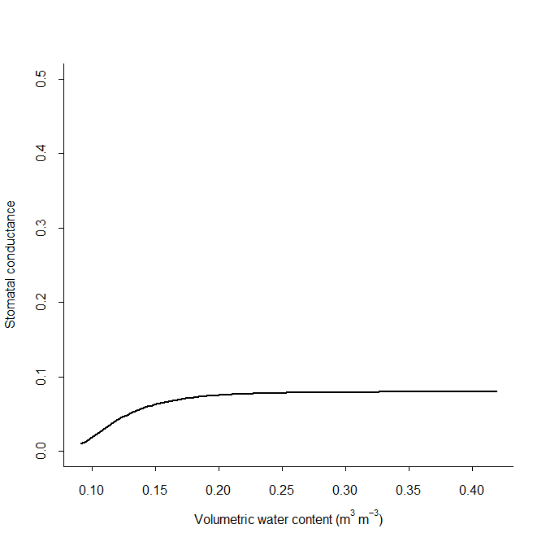

```r
# Check soil parameter table
?micropoint::soilparams

# Select values for clay loam
Smin <- 0.091 # residual volumetric water content
Smax <- 0.419 # volumetric water content at saturation
b <- 5.2      # shape parameter
psie <- 2.6   # air-entry water potential (J/kg)

theta <- seq(Smin, Smax, length.out = 100) # volumetric water content
psi_r <- PsiFromtheta(theta, psie, b, Smax) # soil water potential (MPa)

gs <- stomatalcond_calc(Ca = 400, Rswabs = 500, tair = 20, tleaf = 25,
                        rh = 75, pk = 101.3, psi_r,
                        vegparams, z, C3 = TRUE)

par(mfrow = c(1, 1))

plot(gs ~ theta, type = "l", lwd = 2,
     xlab = expression("Volumetric water content (m"^3 * " m"^-3 * ")"),
     ylab = "Stomatal conductance",
     ylim = c(0, 0.5))
```

Here we see that stomatal conductance is insensitive to soil moisture while the soil is reasonably wet, but declines sharply as it dries.

Next, we scale stomatal conductance from individual leaves to the canopy as a whole. In principle this could be done by summing conductances across all leaves, but a simpler and more practical approach is to assume that the dominant source of within-canopy variation in stomatal conductance is the availability of photosynthetically active radiation (PAR). We therefore partition the canopy into sunlit and shaded components, compute the total sunlit and shaded leaf area per unit ground area, and estimate representative PAR flux densities for each. Leaf-level stomatal conductance is then evaluated under these two light regimes and scaled to the canopy by weighting by the corresponding sunlit and shaded leaf area. This is done using the function `bulkstomatalresist_calc` (which returns resistance as opposed to conductance). To compute the sunlit leaf area we also need to know the sun’s position, hence this is provided as an input. The function also requires the fraction of plant area that is living leaf (`Lfrac`), as woody material does not transpire; here we set it to one. Below we demonstrate how bulk stomatal conductance scales relative to leaf stomatal conductance as a function of plant area.

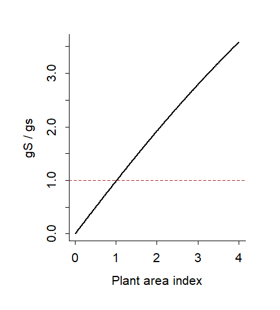

```r
# ===================================================================== #
# ~~~~~~~~~~ Compute leaf stomatal conductance for C3 grass ~~~~~~~~~~~ #
# ===================================================================== #

# Compute sun position at midday on 21 May 2025 in Cornwall, UK
tme <- as.POSIXlt(0, origin = "2025-05-21 12:00", tz = "UTC")
solp <- sunposition(tme, 50, -5)

# Derive vegetation parameters
vegparams <- createplant_inputs("C3")

# Compute absorbed PAR radiation
Rsw <- 800  # shortwave radiation (W m^-2)
Rdif <- 300 # diffuse radiation (W m^-2)

om <- vegparams$lrefp + vegparams$ltrap # leaf reflectance + transmittance (PAR)

k <- cank(solp, x = vegparams$x,
          cos(solp$zen * pi / 180)) # canopy extinction coefficient

# Compute absorbed radiation
# -- (Rsw - Rdif) gives direct beam radiation
# -- k determines the fraction intercepted by leaves
# -- Rdif adds diffuse radiation separately
# -- (1 - om) accounts for absorbed rather than scattered radiation
Rswabs <- (1 - om) * (k * (Rsw - Rdif) + Rdif)

# Compute stomatal conductance
gs <- stomatalcond_calc(Ca = 430, Rswabs, tair = 11, tleaf = 30,
                        rh = 75, pk = 101.3, psi_r = 0,
                        vegparams, z = vegparams$h / 2)

# ===================================================================== #
# ~~~~~~~~ Compute bulk stomatal conductance for C3 grass ~~~~~~~~~~~~~ #
# ===================================================================== #

PAI <- (1:400) / 100 # plant area index
Lfrac <- 1 # fraction of plant area that is living leaf

# Compute bulk stomatal resistance
rS <- 0
vegp2 <- vegparams

for (i in 1:length(PAI)) {
  vegp2$pai <- PAI[i]

  rS[i] <- bulkstomatalresist_calc(solp, Ca = 430, Rsw, Rdif,
                                   tair = 11, tcanopy = 30,
                                   rh = 75, pk = 101.3,
                                   psi_r = 0, vegp2, Lfrac)
}

# Convert to bulk stomatal conductance
gS <- rhoair(11, 101.3) / rS

# ===================================================================== #
# Compute ratio of bulk surface to leaf conductance and plot results
# ===================================================================== #

ratio <- gS / gs

par(mar = c(6, 6, 3, 3))

plot(ratio ~ PAI, type = "l", lwd = 2,
     cex.axis = 1.3, cex.lab = 1.3,
     xlab = "Plant area index",
     ylab = expression(g[S] / g[s]))

abline(h = 1, lty = 2, col = "firebrick")
```

We can see that bulk stomatal conductance rises almost in proportion to plant area index. It falls a little short of doing so because of self-shading: as plant area increases, a greater share of the leaves are shaded and receive less light. The effect is small, as stomatal conductance saturates at low light levels, so shaded leaves conduct almost as much as sunlit ones. When PAI = 4, bulk stomatal conductance is 3.6 times leaf conductance.

### A more complex microclimate model

We now combine the concepts described previously to simulate canopy microclimate using the `solve_wholecanopy` function. For each hour, this function calculates absorbed radiation using `calcRabs`, iteratively solves for diabatic coefficients, friction velocity, and bulk surface stomatal resistance, and updates canopy temperature until convergence. Soil water content and ground heat storage are specified using simplified inputs. Because calculations are performed independently for each hour, the function must be called sequentially to generate a time series; here we illustrate this for June.

We first define input parameters, starting from defaults for a C3 grassland but reducing canopy height and plant area index, and setting the fraction of plant area that is living leaf. Atmospheric CO2 is estimated using functions from `micropoint`, and weather data are subset to June.

We then define vectors for soil water content and ground heat storage and call `solve_wholecanopy` for each hour. Finally, we show how the outputs can be used to estimate air temperature at 0.2 m above ground.

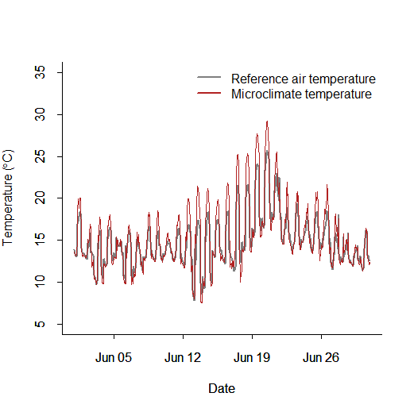

```r
# ----------------------- Create data inputs ------------------------------- #
weather <- climdata

tme <- as.POSIXlt(weather$obs_time, tz = "UTC")
sel <- which(tme$mon + 1 == 6) # select hours in June

weather <- weather[sel,]

groundp <- micropoint::groundparams

vegp <- createplant_inputs("C3")
vegp$h <- 0.12  # vegetation height (m)
vegp$pai <- 0.5 # plant area index
Lfrac <- 0.6    # fraction of plant area that is living leaf

Ca <- micropoint::Cafromyear(2017) # atmospheric CO2 concentration (ppm)

# ------------------- Estimate rate of ground heat storage ----------------- #

# Calculate diurnal temperature range
tday <- matrix(weather$temp, nrow = 24)

tmax <- apply(tday, 2, max, na.rm = TRUE)
tmin <- apply(tday, 2, min, na.rm = TRUE)

dtr <- rep(tmax - tmin, each = 24)

# Simulate sinusoidal daily cycle peaking at 3 pm
daycycle <- sin(pi / 12 * ((0:719) - 9))

# Scale by diurnal temperature range
G <- sqrt(0.5 * dtr) * 25 * daycycle

# -------- Simulate soil water content and surface humidity ---------------- #

theta <- (0.1 * sin(pi / 4380 * ((0:8759) + 2000)) + 0.3)[sel] # root zone
thetas <- (0.15 * sin(pi / 4380 * ((0:8759) + 2000)) + 0.21)[sel] # surface

soilrh <- with(groundp,
               soilrelhum(thetas, 15, Psie, b, Smax))

reqhgt <- 0.2 # target height for air temperature (m)

# ------------------------- Cycle through each hour ------------------------ #

Tz <- 0 # initialise temperature vector

for (hr in 1:720) {

  # --------------------- Run canopy solver -------------------------------- #
  can <- solve_wholecanopy(weather, vegp, groundp, hr,
                           lat = 49.96807, long = -5.215668,
                           zref = 2, G[hr],
                           theta[hr], soilrh[hr], Ca, Lfrac = Lfrac)

  # ---------------- Calculate temperature at reqhgt ----------------------- #

  # Volumetric heat capacity of air
  phcp <- rhoair(weather$temp[hr], weather$pres[hr]) *
          cpair(weather$temp[hr])

  # Resistance to heat transfer between the canopy and reqhgt
  rHa <- canopyresistance(reqhgt, can$uf, vegp$h, vegp$pai, can$LL)

  # Air temperature at reqhgt
  Tz[hr] <- can$tcanopy - (can$H / phcp) * rHa
}

# ----------------------------- Plot results ------------------------------- #

tmem <- as.POSIXct(tme[sel])

# Plot reference air temperature
plot(weather$temp ~ tmem, type = "l",
     xlab = "Date",
     ylab = expression("Temperature (" * degree * "C)"),
     ylim = c(5, 35),
     lwd = 2,
     col = rgb(0, 0, 0, 0.5))

# Plot microclimate air temperature 20 cm above ground
par(new = TRUE)

plot(Tz ~ tmem, type = "l",
     xlab = "Date",
     ylab = "",
     ylim = c(5, 35),
     col = "firebrick")

legend("topright",
       legend = c("Reference air temperature",
                  "Microclimate temperature"),
       col = c(rgb(0, 0, 0, 0.5), "firebrick"),
       lwd = 2,
       bty = "n")
```

Though described as more complex, the processes outlined so far are in fact a simplification, treating the vegetation surface as a homogeneous layer with no vertical temperature variation and a single canopy-scale energy balance. In reality, most canopies exhibit strong vertical temperature gradients, making this assumption inaccurate. Resolving these gradients requires representing the canopy as interacting vertical layers, each with its own energy balance, where conditions reflect both local leaf exchange and heat transported from elsewhere in the canopy. We tackle this in the next section.

## Below canopy

### Two-stream radiation models

A two-stream radiation model extends the concepts introduced for albedo by explicitly representing the downward and upward fluxes of shortwave radiation within the canopy, treating radiation as a set of interacting streams. The downward diffuse stream is attenuated as a function of cumulative plant area, with a proportion of this radiation reflected upward and subsequently scattered back downward, leading to repeated exchanges between upward and downward diffuse fluxes. In parallel, the direct stream is attenuated as it penetrates the canopy, again as a function of cumulative plant area, but also depending on leaf inclination, represented by the parameter x as in the albedo formulation. A fraction of the direct radiation is scattered and reflected, contributing to both the upward and downward diffuse streams and thereby coupling the direct and diffuse components.

The `twostream` function implements these processes by combining vegetation properties (leaf area, reflectance, and transmittance) with ground surface characteristics (reflectance, slope, and aspect), together with information on solar position and the total and diffuse downward fluxes at the top of the canopy. The function returns the downward and upward diffuse fluxes, the downward direct flux, as well as the shortwave radiation absorbed by leaves and the underlying ground surface.

To illustrate the application of the `twostream` function, we first create the necessary vegetation inputs, including a profile of plant area index values at multiple heights in the canopy. We use inbuilt datasets and functions in the `micropoint` package to do this:

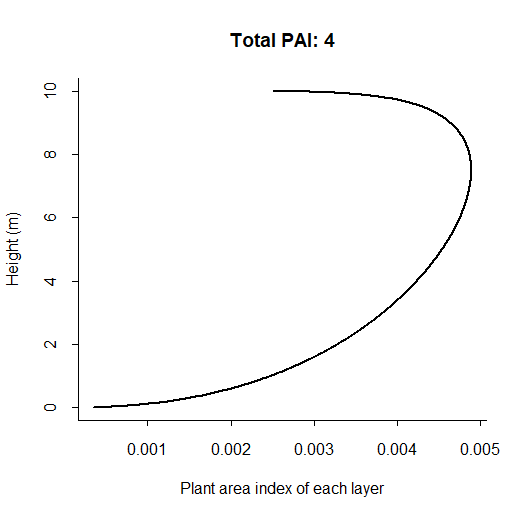

```r
# Use inbuilt vegetation parameter dataset from micropoint package
vegp <- micropoint::forestparams

# Generate vertical profile of plant area index using micropoint::PAIgeometry
paii <- micropoint::PAIgeometry(PAI = vegp$pai,
                                skew = vegp$skew,
                                spread = vegp$spread,
                                n = 1000)

z <- ((1:1000) / 1000) * vegp$h # height above ground (m)

plot(z ~ paii, type = "l", lwd = 2,
     xlab = "Plant area index of each layer",
     ylab = "Height (m)",
     main = paste0("Total PAI: ", round(sum(paii), 2)))
```

Next we generate the rest of the required inputs:

```r
# Extract data for a sunny hour
weather <- climdata

swdown <- weather$swdown[4094] # incoming shortwave radiation (W m^-2)
difrad <- weather$difrad[4094] # diffuse radiation (W m^-2)

# Calculate sun position at that hour
tme <- as.POSIXlt(weather$obs_time[4094], tz = "UTC")
solp <- sunposition(tme, lat = 49.96807, long = -5.215668)
```

After that, it is a simple case of running the twostream model. In the example below, we also plot outputs to show how the fluxes vary with height within the canopy.

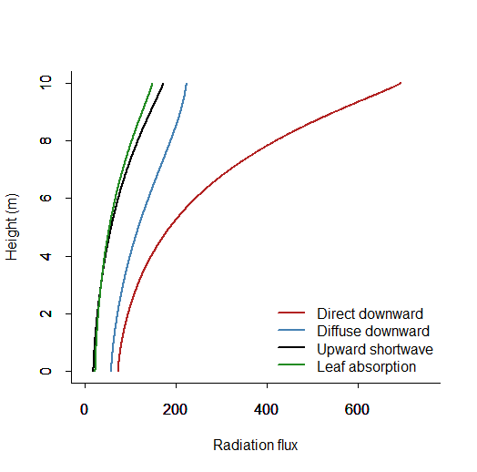

```r
# Run two-stream model and plot radiation fluxes
groundp <- micropoint::groundparams

tsmod <- twostream(vegp, groundp, paii,
                   swdown, difrad, solp)

plot(z ~ tsmod$Rdirdown, type = "l", col = "firebrick", lwd = 2,
     xlab = expression("Radiation flux (W " * m^-2 * ")"),
     ylab = "Height (m)",
     xlim = c(0, 750), ylim = c(0, 10))

par(new = TRUE)
plot(z ~ tsmod$Rdifdown, type = "l", col = "steelblue", lwd = 2,
     xlab = "", ylab = "",
     xlim = c(0, 750), ylim = c(0, 10))

par(new = TRUE)
plot(z ~ tsmod$Rswup, type = "l", col = "black", lwd = 2,
     xlab = "", ylab = "",
     xlim = c(0, 750), ylim = c(0, 10))

par(new = TRUE)
plot(z ~ tsmod$Rleafabs, type = "l", col = "forestgreen", lwd = 2,
     xlab = "", ylab = "",
     xlim = c(0, 750), ylim = c(0, 10))

legend("bottomright",
       legend = c("Direct downward",
                  "Diffuse downward",
                  "Upward shortwave",
                  "Leaf absorption"),
       col = c("firebrick", "steelblue", "black", "forestgreen"),
       lwd = 2,
       bty = "n")
```

The function also returns radiation absorbed by sunlit and shaded leaves separately, as this becomes relevant when computing stomatal conductance. We return to that later.

### Longwave radiation

To calculate downward and upward longwave fluxes, and longwave radiation absorbed by leaves, we require the downward longwave flux from the sky, ground surface temperature, and the temperature profile of the canopy. The `longwavebelow` function combines these inputs to derive the resulting fluxes.

The code below generates a plausible leaf temperature profile, defines inputs, calls the function, and plots the resulting flux profiles.

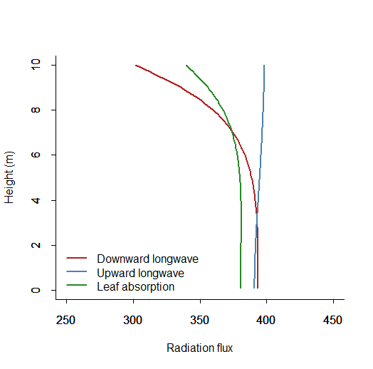

```r
# Create PAI profile using micropoint::PAIgeometry
paii <- micropoint::PAIgeometry(PAI = 4,
                                skew = 7,
                                spread = 70,
                                n = 100)

# Generate leaf temperature profile
z <- (1:100) / 10 # height above ground (m)
tleaf <- 3 * cos(1 - z / 10) + 13.5 # leaf temperature (°C)

# Call longwavebelow function
lwb <- longwavebelow(paii,
                     lwdown = 300,
                     tleaf,
                     tground = 15,
                     vegem = 0.97)

# Plot longwave radiation fluxes
plot(z ~ lwb$Rlwdown, type = "l", col = "firebrick", lwd = 2,
     xlab = expression("Radiation flux (W " * m^-2 * ")"),
     ylab = "Height (m)",
     xlim = c(250, 450), ylim = c(0, 10))

par(new = TRUE)
plot(z ~ lwb$Rlwup, type = "l", col = "steelblue", lwd = 2,
     xlab = "", ylab = "",
     xlim = c(250, 450), ylim = c(0, 10))

par(new = TRUE)
plot(z ~ lwb$RlwLabs, type = "l", col = "forestgreen", lwd = 2,
     xlab = "", ylab = "",
     xlim = c(250, 450), ylim = c(0, 10))

legend("bottomleft",
       legend = c("Downward longwave",
                  "Upward longwave",
                  "Leaf absorption"),
       col = c("firebrick", "steelblue", "forestgreen"),
       lwd = 2,
       bty = "n")
```

### Wind speed

The shape of the wind profile below canopy does not match that above canopy and is partially contingent on the vertical distribution of foliage. We illustrate this by simulating two different foliage profiles and then calculating the wind profile for each using the inbuilt function `windprofile_below`.

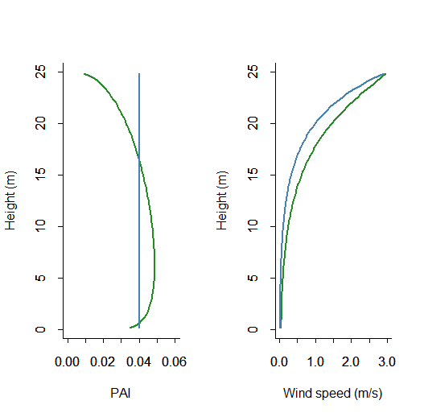

```r
paii_skew <- micropoint::PAIgeometry(PAI = 4,
                                     skew = 3,
                                     spread = 70,
                                     n = 100) # skewed PAI profile

paii_unif <- rep(4 / 100, 100) # uniform PAI profile

# ----------------- Generate wind profiles ------------------------- #

uh <- 3 # wind speed at canopy top (m s^-1)

wind_skew <- windprofile_below(hgt = 25, paii_skew, uh)
wind_unif <- windprofile_below(hgt = 25, paii_unif, uh)

# ----------------------- Plot results ----------------------------- #

z <- ((1:100) - 0.5) / 100 * 25 # height of the middle of each layer (m)

par(mfrow = c(1, 2))

# Foliage profiles
plot(z ~ paii_skew, type = "l", lwd = 2, col = "forestgreen",
     xlab = "Plant area index of each layer",
     ylab = "Height (m)",
     xlim = c(0, 0.06))

par(new = TRUE)
plot(z ~ paii_unif, type = "l", lwd = 2, col = "steelblue",
     xlab = "", ylab = "",
     xlim = c(0, 0.06))

legend("topright",
       legend = c("Skewed profile", "Uniform profile"),
       col = c("forestgreen", "steelblue"),
       lwd = 2,
       bty = "n")

# Wind profiles
plot(z ~ wind_skew, type = "l", lwd = 2, col = "forestgreen",
     xlab = expression("Wind speed (m s"^-1 * ")"),
     ylab = "Height (m)",
     xlim = c(0, 3))

par(new = TRUE)
plot(z ~ wind_unif, type = "l", lwd = 2, col = "steelblue",
     xlab = "", ylab = "",
     xlim = c(0, 3))

legend("bottomright",
       legend = c("Skewed profile", "Uniform profile"),
       col = c("forestgreen", "steelblue"),
       lwd = 2,
       bty = "n")
```

In both canopies, wind speed decreases with depth below the canopy top as foliage absorbs momentum from the moving air. Most of this slowing occurs in the upper canopy, where wind speeds are highest. Further down, the wind is weaker, so foliage exerts less drag and the rate of decrease diminishes. Although both canopies have the same total plant area, wind speeds are higher throughout the skewed canopy. Its sparse upper crown allows wind to penetrate further, while much of its foliage is concentrated lower down, where wind speeds are already low and drag is consequently weaker. Thus, a canopy with foliage distributed evenly through its depth slows the wind more than one with the same amount of foliage concentrated lower down. Close to the ground, surface drag becomes dominant, bringing wind speed to zero at the surface.

### Thermal diffusivity

So far, the transfer of heat through the air has been described in terms of resistance between two heights: the larger the resistance, the greater the temperature difference needed to carry a given flux of heat between them. This resistance depends on both the distance between the two heights and how efficiently heat is transferred through the air between them. The latter is described by **thermal diffusivity**, which measures how readily turbulence carries heat vertically at a given height. Where the air is vigorously mixed by large eddies, thermal diffusivity is high and heat is transferred easily; where mixing is weak, it is low.

The two quantities are directly related. The inverse of thermal diffusivity gives the resistance per metre of height, so the total resistance between two heights is found by integrating this over the distance between them. Air in which thermal diffusivity is low therefore contributes more resistance per metre than air in which it is high. This explains why much of the resistance between the ground and the air above it arises close to the surface, where turbulent mixing is weakest. Once thermal diffusivity is known at every height, resistance can be calculated between any two heights, including within the canopy. It is therefore useful to examine how thermal diffusivity varies with height.

Between the reference height and the ground, four distinct regions can be recognised, each with a different pattern of turbulent mixing. Well above the canopy, mixing follows Monin-Obukhov Similarity Theory, with eddies generally growing in size with height. Closer to the canopy, within the roughness sublayer, larger eddies generated at canopy top provide additional mixing. Thermal diffusivity at canopy top can be up to three times greater than predicted by standard MOST. Within the canopy, heat is carried by turbulent gusts penetrating from above. These weaken as they pass through the foliage, causing thermal diffusivity to decline with depth. Close to the ground, the size of turbulent eddies is constrained by their height above the surface. This limits mixing further, causing thermal diffusivity to fall to zero at ground level, as it does over bare ground.

How distinct these four regions are depends on canopy density. In a dense forest, the roughness sublayer is well developed because the canopy generates substantial turbulent mixing above it. Within the canopy, foliage weakens the gusts penetrating from above, so thermal diffusivity falls steeply with depth. By the time the air reaches the lower canopy, mixing is already weak, and the additional constraint imposed by the ground becomes important only very close to the surface. As foliage becomes sparse, the roughness sublayer weakens and the influence of the ground extends further upwards. The zero-plane displacement decreases, fewer large eddies are generated at canopy top, and gusts penetrate further towards the ground. Mixing through an increasing proportion of the canopy is therefore limited by proximity to the ground rather than attenuation by foliage. In the limit of no foliage, the canopy and roughness sublayer disappear, leaving the standard bare-ground profile predicted by MOST.

The function `thermaldiffusivity` returns thermal diffusivity at any height between the ground and the reference height. It combines all four regions into a continuous profile, with their extent and strength varying with plant area index, so the same function can be used for surfaces ranging from bare ground to dense forest. The code below illustrates this by calculating thermal diffusivity for a dense forest canopy, a very sparse canopy of the same height, and bare ground, all with the same wind speed at the reference height. Bare ground is specified by setting vegetation height to zero.

[figure not shown]

```r
uref <- 3  # wind speed at reference height (m s^-1)
zref <- 20 # reference height (m)
h <- 7     # vegetation height (m)
z <- seq(0, zref, length.out = 500) # heights above ground (m)

# Dense canopy
uf_dense <- windfric(uref, zref, h, pai = 3, MOST = FALSE) # friction velocity
KH_dense <- thermaldiffusivity(z, uf_dense, h, pai = 3)

# Sparse canopy
uf_sparse <- windfric(uref, zref, h, pai = 0.01, MOST = FALSE)
KH_sparse <- thermaldiffusivity(z, uf_sparse, h, pai = 0.01)

# Bare ground with a roughness length of 0.004 m
uf_bare <- 0.41 * uref / log(zref / 0.004)
KH_bare <- thermaldiffusivity(z, uf_bare, h = 0, pai = 0)

# Plot the three profiles
plot(z ~ KH_dense, type = "l", lwd = 2, col = "forestgreen",
     xlab = expression("Thermal diffusivity (" * m^2 ~ s^-1 * ")"),
     ylab = "Height (m)",
     xlim = c(0, 2.5))
lines(z ~ KH_sparse, lwd = 2, col = "darkorange")
lines(z ~ KH_bare, lwd = 2, col = "black", lty = 2)
abline(h = h, lty = 3) # canopy height

legend("bottomright",
       legend = c("Dense canopy", "Sparse canopy", "Bare ground"),
       col = c("forestgreen", "darkorange", "black"),
       lty = c(1, 1, 2), lwd = 2, bty = "n")
```

### Leaf temperature

To compute leaf temperature, we use `SolveEnergyBalance()`. This requires the relevant resistances to be specified. The resistance to heat loss is calculated with `leafresistance()`, which controls the transfer of heat between the leaf surface and the surrounding air. This depends on wind speed and leaf size and shape: faster wind and smaller leaves reduce resistance, allowing more efficient heat exchange. The function uses standard heat transfer relationships to represent both wind-driven and buoyancy-driven exchange, determining how strongly leaf temperature is coupled to the surrounding air.

Stomatal resistance, described earlier, controls the rate of water vapour loss from the leaf and depends on light, temperature, humidity, and water status. Within the canopy, not all leaves receive the same light: some are directly illuminated (sunlit), while others are shaded. Because stomatal conductance responds strongly to light, it is calculated separately for sunlit and shaded leaves using the radiation from the two-stream model. These are then combined according to the fraction of leaf area that is sunlit at each height, giving an effective stomatal resistance for each layer.

Accurate calculation of absorbed radiation also depends on leaf temperature through longwave exchange, so in principle this should be solved iteratively. Here, however, we simplify by assuming leaf temperature is 1 °C warmer than the air when calculating absorbed radiation. The example below calculates leaf temperature for a typical canopy using the absorbed-radiation procedure described above.

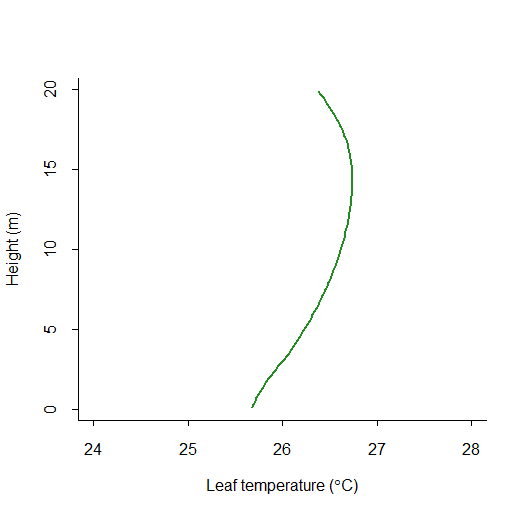

```r
# -------------------------- Derive model inputs -------------------------- #
groundp <- micropoint::groundparams
vegp <- createplant_inputs("BDT") # deciduous broadleaf trees
paii <- micropoint::PAIgeometry(PAI = vegp$pai,
                                skew = 7,
                                spread = 70,
                                n = 100)

# -------------------- Set temperatures and humidity ---------------------- #
tleaf <- rep(26, 100) # initial leaf temperature (°C)
tair <- rep(25, 100)  # air temperature (°C)
tground <- 25         # ground temperature (°C)
rh <- rep(80, 100)    # relative humidity (%)

# ---------------------- Calculate absorbed radiation --------------------- #
# Run two-stream model
tme <- as.POSIXlt(0, origin = "2026-05-21 12:00", tz = "UTC")
solp <- sunposition(tme,
                    lat = 49.96807,
                    long = -5.215668)
tsmod <- twostream(vegp, groundp, paii,
                   swdown = 839,
                   difrad = 223,
                   solp)

# Run longwave model
lwb <- longwavebelow(paii,
                     lwdown = 300,
                     tleaf,
                     tground,
                     vegem = 0.97)
Rabs <- lwb$RlwLabs + tsmod$Rleafabs # absorbed radiation (W m^-2)

# ----------------------- Calculate heat resistance ----------------------- #
uh <- 2 # wind speed at canopy top (m s^-1)
uz <- windprofile_below(vegp$h, paii, uh) # wind profile within canopy

dT <- abs(tleaf - tair) # temperature difference - used with low wind speed
rHa <- leafresistance(tair, dT, uz,
                      vegp$len, vegp$wid, vegp$x)

# -------------------- Calculate stomatal resistance ---------------------- #
# Radiation absorbed by sunlit and shaded leaves, with leaf properties for PAR
tsmod <- twostream(vegp, groundp, paii,
                   swdown = 839,
                   difrad = 223,
                   solp,
                   PAR = TRUE)

z <- ((1:100) - 0.5) / 100 * vegp$h # height of the middle of each layer (m)

# Sunlit leaf stomatal conductance (mol m^-2 s^-1)
gs_sun <- stomatalcond_calc(Ca = 430,
                            tsmod$Rsun,
                            tair,
                            tleaf,
                            rh,
                            pk = 101.3,
                            psi_r = -0.5,
                            vegp,
                            z)

# Shaded leaf stomatal conductance (mol m^-2 s^-1)
gs_shade <- stomatalcond_calc(Ca = 430,
                              tsmod$Rshade,
                              tair,
                              tleaf,
                              rh,
                              pk = 101.3,
                              psi_r = -0.5,
                              vegp,
                              z)

# Combine sunlit and shaded fractions
gs <- gs_sun * tsmod$sunlitfrac +
      (1 - tsmod$sunlitfrac) * gs_shade

ph <- rhoair(tair, pk = 101.3) # air density (mol m^-3)
rS <- ph / gs # stomatal resistance (s m^-1)

# ---------------------- Derive leaf temperature -------------------------- #
tleaf <- SolveEnergyBalance(tair,
                            pk = 101.3,
                            rh,
                            Rabs,
                            rHa,
                            rS,
                            G = 0,
                            em = 0.97,
                            method = "Penman",
                            iters = 4)

# ---------------------- Plot leaf temperature profile -------------------- #
par(mfrow = c(1, 1))
plot(z ~ tleaf, type = "l", lwd = 2, col = "forestgreen",
     xlab = expression("Leaf temperature (" * degree * "C)"),
     ylab = "Height (m)",
     xlim = c(24, 28))
```

Leaves are warmer than the surrounding air throughout the canopy, with temperatures highest about two-thirds of the way up. Two opposing effects determine this pattern. Absorbed radiation increases towards canopy top, warming the leaves, but wind speed also increases, reducing resistance to heat loss. Near the ground, leaves are coolest because they absorb little radiation, despite the weak wind. At canopy top, they absorb the most radiation but lose heat efficiently to the moving air. Between these extremes, leaves receive substantial radiation while remaining sheltered from the wind, producing the highest temperatures.

### Air temperature and humidity

In the earlier examples, air temperature and humidity were treated as known inputs when calculating leaf temperature and longwave radiation. Here we calculate them from the exchange of heat and water vapour within the canopy.

Air temperature at any height depends on heat released by foliage throughout the canopy, not just at that height. The functions `temp_below` and `relhum_below` account for this using Raupach’s (1989a,b) localised near-field approach, which separates the influence of nearby foliage (the **near field**) from that of heat and water vapour transported through the canopy as a whole (the **far field**). Together, these determine the vertical profiles of air temperature and humidity.

We illustrate the two components separately using `farfield` and `nearfield`. Both require the heat released by each canopy layer. Later we calculate this from leaf temperature, but for now we make the simplifying assumption that half the radiation absorbed by each layer is released as sensible heat. We use 500 W m<sup>-2</sup> of radiation at canopy top, giving a total sensible heat flux of about 200 W m<sup>-2</sup>. Rather than the smooth foliage profiles used previously, we use the inbuilt dataset `wythampai`, a plant area profile measured by laser scanning at Wytham Woods, Oxfordshire, by Calders et al. (2023). This has the uneven vertical distribution of foliage characteristic of real woodland.

#### The far field

The far field describes how heat released throughout the canopy is distributed by turbulent mixing. Heat from each layer is transferred through the air above and below it, with the resulting temperature profile determined by the heat sources, the resistance to heat transfer between heights, and the temperatures at canopy top and the ground. The function `farfield` calculates this using the thermal diffusivity profile described earlier, determined from canopy height, plant area index and friction velocity.

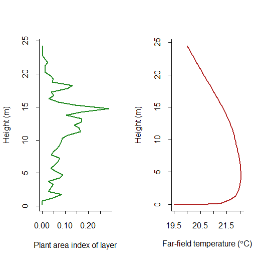

```r
# ------------------------- Foliage profile ------------------------------- #
paii <- wythampai$paii # plant area index of each layer
z <- wythampai$z       # height of the middle of each layer (m)
hgt <- 24.5            # canopy height (m)
pai <- sum(paii)       # plant area index of the whole canopy

# ---------------- Heat released by each canopy layer --------------------- #
Rnet <- 500 # radiation at canopy top available to heat the canopy (W m^-2)
k <- 0.5    # extinction coefficient: how strongly foliage attenuates radiation

# Fraction of that radiation passing the top and the bottom of each layer
pabove <- rev(cumsum(rev(paii))) - paii # plant area above the top of each layer
trtop <- exp(-k * pabove)
trbottom <- exp(-k * (pabove + paii))

# Half of the radiation absorbed by each layer is released as sensible heat
Hz <- 0.5 * Rnet * (trtop - trbottom) # sensible heat flux (W m^-2 of ground)

# ----------------------- Far-field temperature --------------------------- #
uf <- 0.2       # friction velocity (m s^-1)
ttop <- 20      # air temperature at canopy top (°C)
tground <- 19.5 # ground surface temperature (°C)

# Heights from the ground surface to canopy top (m), closely spaced near the ground
zall <- c(0, 0.02, 0.05, 0.1, z, hgt)
tfar <- farfield(Hz, hgt, pai, uf,
                 top = ttop,
                 ground = tground,
                 tair = ttop, # sets the density and heat capacity of air
                 z = zall)

# ---------------------------- Plot results ------------------------------- #
par(mfrow = c(1, 2))
plot(z ~ paii, type = "l", lwd = 2, col = "forestgreen",
     xlab = "Plant area index of layer",
     ylab = "Height (m)")
plot(zall ~ tfar, type = "l", lwd = 2, col = "firebrick",
     xlab = expression("Far-field temperature (" * degree * "C)"),
     ylab = "Height (m)")
```

Foliage is densest between 11 and 19 m, with a sharp peak around 15 m, and this is where most of the heat is released. Despite this uneven distribution, the far-field temperature profile is smooth. Temperature increases from 20 °C at canopy top to about 22 °C at 4 m, because most of the heat must flow upwards through the air above it. Below this, the profile turns towards the cooler ground surface, which absorbs a small proportion of the heat released within the canopy.

#### The near field

The far field describes heat that has become dispersed by turbulent mixing. Immediately after heat leaves a leaf, however, it remains concentrated in the air moving away from its source. This produces a local warming beyond that predicted by the far field alone, known as the near field. Its influence extends over a relatively short distance, typically around a metre, so it reflects the foliage and heat sources close to each height.

The function `nearfield` calculates this additional warming using the same canopy properties and heat fluxes. Adding the near and far fields gives the air temperature profile.

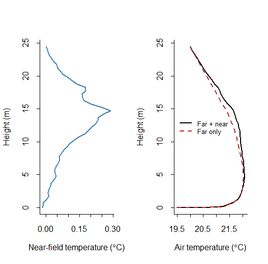

```r
# ----------------------- Near-field temperature -------------------------- #
tnear <- nearfield(Hz, hgt, pai, uf,
                   tair = ttop, # sets the density and heat capacity of air
                   z = zall)

# --------------------------- Air temperature ----------------------------- #
tair <- tfar + tnear

# ---------------------------- Plot results ------------------------------- #
par(mfrow = c(1, 2))
plot(zall ~ tnear, type = "l", lwd = 2, col = "steelblue",
     xlab = expression("Near-field temperature (" * degree * "C)"),
     ylab = "Height (m)")
plot(zall ~ tair, type = "l", lwd = 2, col = "black",
     xlab = expression("Air temperature (" * degree * "C)"),
     ylab = "Height (m)")
lines(zall ~ tfar, lwd = 2, col = "firebrick", lty = 2)
legend("left",
       legend = c("Far + near", "Far only"),
       col = c("black", "firebrick"),
       lty = c(1, 2), lwd = 2, bty = "n", cex = 0.8)
```

The near-field contribution is small, reaching about 0.3 °C, but follows the uneven distribution of foliage. It is greatest around 13–15 m, where most heat is released, and much smaller in the sparse upper crown and near the ground. Adding it to the far field therefore introduces local variation into the otherwise smooth temperature profile. Near-field warming increases with heat release and becomes more pronounced when wind speeds are low.

The same approach applies to humidity. Setting `vapour = TRUE` and supplying latent rather than sensible heat fluxes allows `farfield` and `nearfield` to calculate the corresponding contributions to vapour pressure, using vapour pressures at canopy top and the ground in place of temperatures.

#### Coupling leaves and air

The near and far fields are combined by `temp_below` and `relhum_below`, which calculate air temperature and relative humidity from the sensible and latent heat fluxes of each canopy layer.

So far, these fluxes have been prescribed. In reality, they depend on leaf temperature, which itself depends on the surrounding air. We therefore need to solve leaf and air conditions together. Starting with estimates of air temperature and humidity, we calculate leaf temperature and the resulting heat and vapour fluxes, update the air profiles, and repeat until the solution converges.

For this example we use the Wytham Woods foliage profile and weather conditions for the hottest hour in `climdata`. The function `solve_wholecanopy` provides conditions at canopy top and the wind parameters needed for turbulent mixing, including the roughness sublayer (`MOST = FALSE`). We assume vapour pressure is unchanged between the reference height and canopy top, and set ground temperature 1 °C below canopy-top air temperature.

Shortwave radiation and wind speed are calculated once, before the loop. At each iteration we update absorbed longwave radiation, leaf resistances and leaf temperature, then calculate the sensible and latent heat fluxes as in the earlier examples. These are converted from fluxes per unit leaf surface to fluxes per unit ground area by multiplying by twice the plant area index of each layer, accounting for exchange from both sides of the leaves. Finally, `temp_below` and `relhum_below` update the air profiles. The loop stops when the maximum change in air temperature is less than 0.001 °C; here it takes seven iterations.

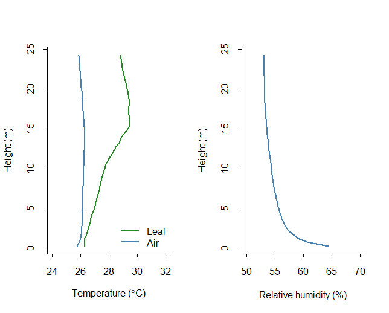

```r
# -------------------------- Derive model inputs -------------------------- #
weather <- climdata
groundp <- micropoint::groundparams
vegp <- createplant_inputs("BDT") # broadleaf deciduous trees
paii <- wythampai$paii            # plant area index of each layer
z <- wythampai$z                  # height of the middle of each layer (m)
n <- length(paii)                 # number of canopy layers
vegp$h <- 24.5                    # canopy height (m)
vegp$pai <- sum(paii)             # plant area index of the whole canopy
Ca <- micropoint::Cafromyear(2017) # atmospheric CO2 concentration (ppm)

# --------- Run canopy solver to derive conditions at canopy top ---------- #
lat <- 49.96807
long <- -5.215668
hr <- 4094
can <- solve_wholecanopy(weather, vegp, groundp, hr,
                         lat, long,
                         zref = 30,
                         G = 20,
                         theta = 0.2,
                         soilrh = 87,
                         Ca,
                         MOST = FALSE,
                         Lfrac = 0.6)

# ---------------------- Set reference climate variables ------------------ #
lwdown <- weather$lwdown[hr] # downward longwave radiation (W m^-2)
swdown <- weather$swdown[hr] # downward shortwave radiation (W m^-2)
difrad <- weather$difrad[hr] # diffuse radiation (W m^-2)
pk <- weather$pres[hr]       # pressure (kPa)
uf <- can$uf                 # friction velocity (m s^-1)
LL <- can$LL                 # Obukhov length (m)
uh <- can$uh                 # wind speed at canopy top (m s^-1)
th <- can$th                 # air temperature at canopy top (°C)

# Relative humidity at canopy top (%), from vapour pressure at reference height
eref <- satvap(weather$temp[hr]) * weather$relhum[hr] / 100
rhtop <- 100 * eref / satvap(th)

tground <- th - 1 # ground surface temperature (°C)
soilrh <- 87      # effective relative humidity of the soil surface (%)
psi_r <- -0.5     # root-zone water potential (MPa)

# ---------------- Initial guesses of below-canopy profiles --------------- #
tleaf <- rep(th + 1, n) # leaf temperature (°C)
tair <- rep(th, n)      # air temperature (°C)
rh <- rep(rhtop, n)     # relative humidity (%)

# --------------------- Calculate shortwave radiation --------------------- #
tme <- as.POSIXlt(weather$obs_time[hr], tz = "UTC")
solp <- sunposition(tme, lat, long) # zenith and azimuth angles
tsmod <- twostream(vegp, groundp, paii,
                   swdown, difrad, solp)
# With leaf properties for PAR, for the stomatal calculations
tspar <- twostream(vegp, groundp, paii,
                   swdown, difrad, solp,
                   PAR = TRUE)

# ------------------------- Calculate wind profile ------------------------ #
uz <- windprofile_below(vegp$h, paii, uh) # wind speed of each layer (m s^-1)

# -------------------------- Initialise while loop ------------------------ #
error <- 1e99
itr <- 0

while (error > 1e-3) {

  # ------------------- Calculate absorbed radiation ---------------------- #
  lwb <- longwavebelow(paii,
                       lwdown,
                       tleaf,
                       tground,
                       vegem = 0.97)
  Rabs <- lwb$RlwLabs + tsmod$Rleafabs # absorbed radiation (W m^-2)

  # --------------------- Calculate heat resistance ----------------------- #
  dT <- abs(tleaf - tair) # leaf-air temperature difference (°C)
  rHa <- leafresistance(tair, dT, uz,
                        vegp$len, vegp$wid, vegp$x)

  # ------------------ Calculate stomatal resistance ---------------------- #
  gs_sun <- stomatalcond_calc(Ca,
                              tspar$Rsun,
                              tair,
                              tleaf,
                              rh,
                              pk,
                              psi_r,
                              vegp,
                              z)

  gs_shade <- stomatalcond_calc(Ca,
                                tspar$Rshade,
                                tair,
                                tleaf,
                                rh,
                                pk,
                                psi_r,
                                vegp,
                                z)

  gs <- gs_sun * tspar$sunlitfrac +
        (1 - tspar$sunlitfrac) * gs_shade

  ph <- rhoair(tair, pk) # air density (mol m^-3)
  rS <- ph / gs          # stomatal resistance (s m^-1)

  # --------------------- Derive leaf temperature ------------------------- #
  tleaf <- SolveEnergyBalance(tair,
                              pk,
                              rh,
                              Rabs,
                              rHa,
                              rS,
                              G = 0,
                              em = 0.97,
                              method = "Penman",
                              iters = 4)

  # ------------- Heat and vapour released by each layer ------------------ #
  # Per unit leaf surface (W m^-2)
  cp <- cpair(tair)                # heat capacity of air (J mol^-1 K^-1)
  es <- satvap(tleaf)              # vapour pressure of the leaf (kPa)
  ea <- satvap(tair) * (rh / 100)  # vapour pressure of the air (kPa)
  H <- (ph * cp / rHa) * (tleaf - tair)                    # sensible heat
  L <- (latvap(tleaf) * ph / ((rHa + rS) * pk)) * (es - ea) # latent heat

  # Per unit ground area: both sides of the leaves, times plant area
  Hz <- 2 * paii * H
  Lz <- 2 * paii * L

  # --------------------- Calculate air temperature ----------------------- #
  tairn <- temp_below(Hz, vegp$h, vegp$pai, uf,
                      ttop = th,
                      tground = tground,
                      tair = tair,
                      pk = pk,
                      LL = LL)

  # --------------------- Calculate relative humidity --------------------- #
  rh <- relhum_below(Lz, vegp$h, vegp$pai, uf,
                     rhtop = rhtop,
                     ttop = th,
                     tground = tground,
                     soilrh = soilrh,
                     tair = tairn,
                     pk = pk,
                     LL = LL)

  # ------------------------ Check for convergence ------------------------ #
  error <- max(abs(tairn - tair))
  tair <- tairn
  itr <- itr + 1
}

# ----------------------------- Plot results ------------------------------ #
par(mfrow = c(1, 2))
# Temperature profiles
plot(z ~ tleaf, type = "l", col = "forestgreen", lwd = 2,
     xlim = c(24, 32),
     xlab = expression("Temperature (" * degree * "C)"),
     ylab = "Height (m)")
lines(z ~ tair, col = "steelblue", lwd = 2)
legend("bottomright",
       legend = c("Leaf", "Air"),
       col = c("forestgreen", "steelblue"),
       lwd = 2,
       bty = "n")

# Relative humidity profile of the air
plot(z ~ rh, type = "l", col = "steelblue", lwd = 2,
     xlim = c(50, 70),
     xlab = "Relative humidity (%)",
     ylab = "Height (m)")
```

Leaves are 0.5–3.5 °C warmer than the surrounding air, with the highest temperatures around 15 m, where radiation absorption is greatest. Air temperature varies much less, rising from 25.9 °C at canopy top to 26.4 °C near 15 m before falling to 25.8 °C towards the cooler ground. Relative humidity remains close to 53% through the upper canopy, then rises to 64% near the moist ground as the air cools and water evaporates from the soil.

Here ground temperature is prescribed and the ground heat flux is approximated. The next section shows how both can be calculated explicitly.

## Ground heat storage

During the day, the ground warms and heat flows into the soil; at night, the flow reverses. How quickly soil stores and releases heat depends on two properties: **thermal conductivity**, which determines how readily heat flows through it, and **volumetric heat capacity**, which determines how much energy is needed to raise its temperature. As with the canopy example above, we can think of the soil as a series of vertical layers, with heat conducted between layers and stored within each.

Both properties depend on soil composition and moisture. Soil consists of mineral particles, organic matter, water and air. The proportions of solid constituents are treated as fixed properties of each soil type, with typical values provided in the `micropoint` table `newsoilparamstable`. Water content, however, varies over time and strongly influences both thermal properties. Water conducts heat over twenty times more effectively than air and has a volumetric heat capacity several thousand times greater. As water replaces air in soil pores, both conductivity and heat capacity increase.

Below, we use `thermalConductivity` and `heatCapacity` to examine how these properties vary with water content in a clay loam, from nearly dry to saturated. Temperature and pressure affect the properties of pore air, while temperature also determines whether soil water is frozen.

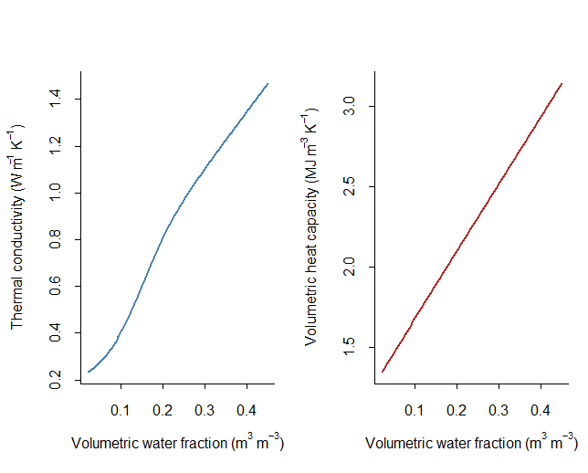

```r
# Composition of a typical clay loam
Vq <- 0.0568 # volumetric quartz fraction
Vm <- 0.4818 # volumetric fraction of other minerals
Vo <- 0.0114 # volumetric organic fraction
Mc <- 0.34 # mass fraction of clay

# Volumetric water fraction, from almost dry to saturated
Vw <- seq(0.02, 0.45, length.out = 100)

# Thermal conductivity (W m^-1 K^-1)
k <- thermalConductivity(Vq, Vm, Vo, Vw, Mc,
                         Tc = 15,    # soil temperature (°C)
                         pk = 101.3) # atmospheric pressure (kPa)

# Volumetric heat capacity (MJ m^-3 K^-1)
Ch <- heatCapacity(Vq, Vm, Vo, Vw,
                   Tc = 15,
                   pk = 101.3) / 1e6

# Plot both against water content
par(mfrow = c(1, 2))
plot(k ~ Vw, type = "l", lwd = 2, col = "steelblue",
     xlab = expression("Volumetric water fraction (m"^3 * " m"^-3 * ")"),
     ylab = expression("Thermal conductivity (W m"^-1 * " K"^-1 * ")"))
plot(Ch ~ Vw, type = "l", lwd = 2, col = "firebrick",
     xlab = expression("Volumetric water fraction (m"^3 * " m"^-3 * ")"),
     ylab = expression("Volumetric heat capacity (MJ m"^-3 * " K"^-1 * ")"))
```

Heat capacity increases linearly with water content, from about 1.3 to 3.1 MJ m<sup>-3</sup> K<sup>-1</sup>, because it is the sum of the heat capacities of the soil constituents weighted by their volumes. Thermal conductivity increases more than sixfold, from about 0.2 to 1.5 W m<sup>-1</sup> K<sup>-1</sup>, with the steepest increase at intermediate moisture levels. In dry soil, heat passes between particles mainly at their points of contact. As the soil wets, water bridges the gaps between particles, allowing heat to flow more readily.

The ratio of thermal conductivity to volumetric heat capacity is known as **thermal diffusivity**. It determines how rapidly temperature changes propagate through the soil. Here, diffusivity more than doubles between dry and saturated conditions, allowing daily temperature fluctuations to penetrate deeper into wet soil.

### Simple estimates

Ground heat storage is difficult to calculate explicitly, so we begin with a simplified approach before introducing a more complete model. We assume that the soil is infinitely deep, has uniform thermal properties and experiences a sinusoidal daily cycle in surface temperature. Under these conditions, ground heat flux also varies sinusoidally, peaking three hours before surface temperature. Its magnitude depends on the amplitude of the temperature cycle, soil thermal conductivity and the *damping depth*: the depth at which temperature fluctuations fall to 37% of their surface amplitude. Damping depth is determined by the soil’s thermal diffusivity.

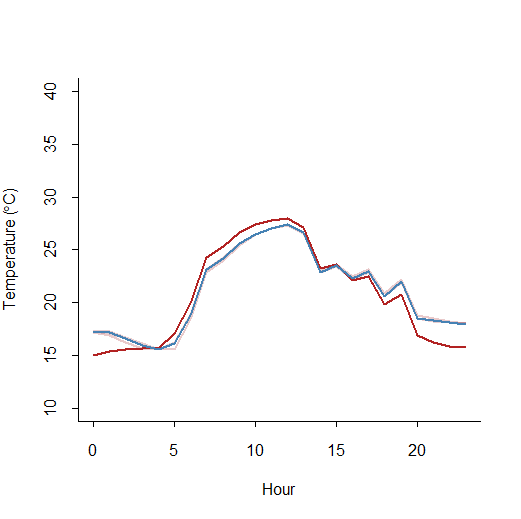

```r
# ----------------------------- Model inputs ------------------------------ #
weather <- climdata
tme <- as.POSIXlt(weather$obs_time, tz = "UTC")
sel <- which(tme$mon + 1 == 6 &
             tme$mday == 21) # select hours of 21 June
weather <- weather[sel, ]

groundp <- micropoint::groundparams # ground parameters

vegp <- createplant_inputs("C3") # vegetation parameters
vegp$h <- 0 # vegetation height (m): zero for bare ground
vegp$pai <- 0 # plant area index: zero for bare ground

# --------------------- Thermal properties of the soil -------------------- #
# Clay loam with a volumetric water fraction of 0.3
k <- thermalConductivity(Vq = 0.0568, Vm = 0.4818, Vo = 0.0114,
                         Vw = 0.3, Mc = 0.34,
                         Tc = 15, pk = 101.3) # thermal conductivity (W m^-1 K^-1)
Ch <- heatCapacity(Vq = 0.0568, Vm = 0.4818, Vo = 0.0114,
                   Vw = 0.3,
                   Tc = 15, pk = 101.3) # heat capacity (J m^-3 K^-1)

tt <- 0:23        # hours of day
om <- 2 * pi / 24 # angular frequency of the daily cycle (radians per hour)
ka <- k / Ch      # thermal diffusivity (m^2 s^-1)
DampDepth <- sqrt(2 * ka * 3600 / om) # damping depth (m)

# -------------------------- Initialise variables ------------------------- #
G <- rep(0, 24) # ground heat flux (W m^-2)
error <- 1e99   # difference from previous iteration
Told <- 0       # temperature in previous iteration
itr <- 1        # iteration counter

cols <- adjustcolor(colorRampPalette(c("firebrick", "steelblue"))(12),
                    alpha.f = 0.25)

while (error > 1e-3) {
  # ------------------------ Cycle through each hour ---------------------- #
  Ts <- 0 # initialise surface temperature

  for (hr in 1:24) {
    can <- solve_wholecanopy(weather, vegp, groundp,
                             hr,
                             lat = 49.96807,
                             long = -5.215668,
                             zref = 2,
                             G[hr],
                             theta = 0.3,
                             soilrh = 85)
    Ts[hr] <- can$tcanopy # surface temperature (°C)
  }

  # Plot diurnal temperature on each iteration
  if (itr == 1) {
    plot(Ts ~ tt, type = "l", col = "firebrick",
         ylim = c(10, 40),
         xlab = "Hour",
         ylab = expression("Temperature (" * degree * "C)"),
         lwd = 2)
  } else {
    lines(Ts ~ tt, col = cols[min(itr, 12)], lwd = 2)
  }

  # ---------- Fit a sinusoidal cycle to surface temperature -------------- #
  m <- lm(Ts ~ sin(om * tt) + cos(om * tt))
  # Decimal hour at which the fitted cycle peaks
  hrmx <- as.numeric(((pi / 2 -
            atan2(coef(m)[3], coef(m)[2])) / om) %% 24)
  A0 <- (max(Ts) - min(Ts)) / 2 # amplitude of temperature cycle (°C)

  # ------------------------ Calculate ground flux ------------------------ #
  # Peaks three hours (a phase of pi / 4) before surface temperature
  G <- sqrt(2) * A0 * k / DampDepth *
       sin(om * (tt - hrmx) + 3 * pi / 4)

  error <- max(abs(Ts - Told)) # convergence error
  Told <- Ts
  itr <- itr + 1
}

# ---------------------- Plot final converged temperature ----------------- #
lines(Ts ~ tt, col = "steelblue", lwd = 2)
```

The same approach can be used to estimate temperatures below the surface. As depth increases, daily temperature fluctuations become smaller and their peaks occur progressively later. Below, we calculate temperature cycles at 5 cm and 20 cm depth, comparing them with the modelled surface temperature and its sinusoidal approximation.

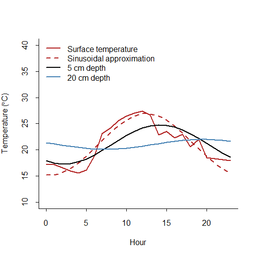

```r
# Assumes code above already run
Tav <- mean(Ts) # average temperature (°C)

# ---------------- Temperatures at 5 cm depth ---------------------------- #
z <- -0.05 # depth below surface (m)
Tz5 <- Tav + A0 * exp(z / DampDepth) *
       sin(om * (tt - hrmx) + pi / 2 + z / DampDepth)

# ---------------- Temperatures at 20 cm depth --------------------------- #
z <- -0.2 # depth below surface (m)
Tz20 <- Tav + A0 * exp(z / DampDepth) *
        sin(om * (tt - hrmx) + pi / 2 + z / DampDepth)

# Assumed sinusoidal cycle at the surface
Tz0 <- Tav + A0 * sin(om * (tt - hrmx) + pi / 2)

# ----------------------------- Plot results ----------------------------- #
plot(Ts ~ tt, type = "l", col = "firebrick",
     ylim = c(10, 40),
     xlab = "Hour",
     ylab = expression("Temperature (" * degree * "C)"),
     lwd = 2)
lines(Tz0 ~ tt, col = "firebrick", lwd = 2, lty = 2)
lines(Tz5 ~ tt, col = "black", lwd = 2)
lines(Tz20 ~ tt, col = "steelblue", lwd = 2)
legend("topleft",
       legend = c("Surface temperature",
                  "Sinusoidal approximation",
                  "5 cm depth",
                  "20 cm depth"),
       col = c("firebrick", "firebrick", "black", "steelblue"),
       lty = c(1, 2, 1, 1),
       lwd = 2,
       bty = "n")
```

This approach captures the main features of ground heat storage and the attenuation of temperature fluctuations with depth, but its assumptions are restrictive. Surface temperature rarely follows a perfect sinusoidal cycle, while soil thermal properties vary with depth and changing water content. We therefore turn to a more comprehensive model that relaxes these assumptions.

### Soil temperature model

We now move to a more realistic model in which the soil is divided into vertical layers. Heat flows between adjacent layers according to their thermal conductivity and temperature differences, while the resulting temperature change in each layer depends on its heat capacity. At the surface, temperature is determined by the balance between absorbed radiation, emitted longwave radiation and sensible and latent heat exchange with the air.

At each timestep, the temperatures of all soil layers are calculated simultaneously by solving the heat equation using a tridiagonal matrix using function `SoilHeatModel`. Because surface heat exchange itself depends on surface temperature, the calculation is iterated until the surface energy balance converges. Temperature is held fixed at the lower boundary, typically at a depth where daily fluctuations are negligible.

We first use `createsoilplist` to define the soil profile, specifying its type, depth and number of layers. The function assigns default values for the proportions of quartz, other minerals, clay and organic matter. Organic matter can also be concentrated near the surface using `surface_organicmu`. Here we use a 2 m clay loam profile with 15 layers and three times the average organic matter content in the surface layer. Other available soil types can be determined by inspecting the `createsoilplist` help file.

```r
# -------------- Generate list of soil model parameters --------------- #
soilp <- createsoilplist(soiltype = "Clay loam",
                         nlayers = 15, # number of soil layers
                         totalDepth = 2, # total soil depth (m)
                         slope = 0, # slope (degrees)
                         aspect = 180, # aspect (degrees)
                         surface_organicmu = 3, # surface organic matter depth
                         FreeDrain = TRUE) # free drainage lower boundary
```

The `FreeDrain` argument controls the lower boundary of the soil water model, described later. We initialise the temperature and moisture profiles using `InitSoilheatmod`:

```r
# Initial soil temperature sequence: surface to lower boundary layer
Te <- seq(18, 11, length.out = 16)
theta <- rep(0.3, 16) # volumetric soil water fraction
soilheat <- InitSoilheatmod(soilp, Te, theta)
```

This creates the initial soil state, with layers spaced more closely near the surface where temperature changes most rapidly. The final temperature specifies the fixed lower boundary, for which mean annual temperature is a reasonable approximation. Each subsequent call to `SoilHeatModel` advances the temperature profile by one timestep and calculates the rate of ground heat storage (`Gflux`).

Below, we simulate 10 days in June for bare ground. With vegetation height and plant area index set to zero, `solve_wholecanopy` treats the surface as bare soil. At each hour it provides the radiation absorbed by the ground and the resistance to heat transfer between the ground and reference height, which depends on wind speed and on the stability of the air. These inputs are passed to `SoilHeatModel`, which calculates surface and subsurface temperatures and ground heat flux. Because the stability of the air depends on how much heat the surface gives to it, and so on ground heat flux, the two calculations are iterated until the flux converges. The resulting soil temperatures are then carried forward to the next hour (`soilheat$oldTe <- soilheat$Te`).

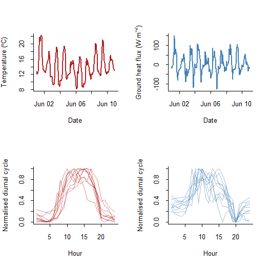

```r
# ---------------- Create driving data from inbuilt datasets -------------- #
weather <- climdata
groundp <- micropoint::groundparams

vegp <- createplant_inputs("C3")
vegp$h <- 0 # vegetation height (m): zero for bare ground
vegp$pai <- 0 # total plant area index: zero for bare ground

lat <- 49.96807 # latitude (decimal degrees)
long <- -5.215668 # longitude (decimal degrees)

boundaryT <- mean(weather$temp) # lower boundary temperature (°C)

# ---------------- Select data for first 10 days in June ----------------- #
tme <- as.POSIXlt(weather$obs_time, tz = "UTC")

sel <- which(tme$mon + 1 == 6 &
             tme$mday < 11)

weather <- weather[sel,]
tme <- tme[sel]

# ---------------- Create parameters for soil heat model ----------------- #
soilp <- createsoilplist(soiltype = "Clay loam",
                         nlayers = 15, # number of soil layers
                         totalDepth = 2, # total soil depth (m)
                         slope = 0, # slope (degrees)
                         aspect = 180, # aspect (degrees)
                         surface_organicmu = 3, # surface organic matter depth
                         FreeDrain = TRUE) # free drainage lower boundary

Te <- seq(weather$temp[1],
          boundaryT,
          length.out = 16) # initial temperature profile (°C)

theta <- rep(0.3, 16) # volumetric water content

soilheat <- InitSoilheatmod(soilp, Te, theta) # initialise soil heat model

# -------------------------- Initialise variables ------------------------- #
error <- 1e99 # error tolerance for iterative solve
G <- 0 # ground heat flux (W m^-2)

Tsurface <- rep(0, 240) # ground surface temperature (°C)
Gflux <- rep(0, 240) # ground heat flux for each timestep

for (hr in 1:240) {

  while (error > 1e-4) {

     # ------ Absorbed radiation and resistance to heat transfer --------- #
     can <- solve_wholecanopy(weather, vegp, groundp,
                              hr,
                              lat,
                              long,
                              zref = 2,
                              G,
                              theta = 0.3,
                              soilrh = 100) # moist soil: air at its surface is saturated

     # ------------------------- Run soil heat model --------------------- #
     soilheat <- SoilHeatModel(soilheat,
                               soilp,
                               Rabs = can$Rabs, # radiation absorbed by the ground
                               Tref = weather$temp[hr],
                               relhum = weather$relhum[hr],
                               atmPressure = weather$pres[hr],
                               rHa = can$rHg) # resistance from ground to zref

     error <- abs(G - soilheat$Gflux) # convergence error
     G <- soilheat$Gflux
  }

  Gflux[hr] <- G
  Tsurface[hr] <- soilheat$Te[1]

  soilheat$oldTe <- soilheat$Te # update model state

  error <- 1e99 # reset convergence criterion
}

# ----------------------------- Plot time series -------------------------- #
par(mfrow = c(2, 2))

tmec <- as.POSIXct(tme, tz = "UTC")

# Soil surface temperature
plot(Tsurface ~ tmec, type = "l", lwd = 2, col = "firebrick",
     xlab = "Date",
     ylab = expression("Temperature (" * degree * "C)"))

# Ground heat flux
plot(Gflux ~ tmec, type = "l", lwd = 2, col = "steelblue",
     xlab = "Date",
     ylab = expression("Ground heat flux (W " * m^-2 * ")"))

# ---------------- Plot normalised diurnal cycle ------------------------- #

# Values are scaled between each day's minimum and maximum
# to emphasise differences in diurnal shape among days

plotdailycycle <- function(v, clr) {

  # Convert hourly vector into day × hour matrix
  vd <- matrix(v, ncol = 24, byrow = TRUE)

  # Daily minima and maxima
  vmn <- apply(vd, 1, min)
  vmx <- apply(vd, 1, max)

  # Scale values between 0 and 1
  vdfrac <- (vd - vmn) / (vmx - vmn)

  # Plot each daily cycle
  matplot(t(vdfrac), type = "l", lty = 1,
          col = clr,
          xlab = "Hour",
          ylab = "Normalised diurnal cycle")
}

# Plot daily cycles for surface temperature and ground heat flux
plotdailycycle(Tsurface, rgb(0.7, 0.13, 0.13, 0.5))
plotdailycycle(Gflux, rgb(0.27, 0.51, 0.71, 0.5))
```

The plots show pronounced daily cycles in both surface temperature and ground heat flux, with variations between days reflecting changing weather conditions. The lower panels rescale each day’s cycle to highlight their timing. Ground heat flux typically peaks in mid-morning, several hours before surface temperature, consistent with the simpler model above. Unlike that model, however, the timing and magnitude of heat exchange are now calculated directly from the evolving soil temperature profile rather than assuming a sinusoidal cycle.

Bare ground is the simplest case. Beneath vegetation, the ground absorbs only the shortwave radiation that passes through the canopy, together with longwave radiation emitted by the canopy itself. It also exchanges heat and water vapour with air that the foliage has warmed, cooled or moistened, and in turn alters that air and so the temperature of the leaves. The ground, the canopy and the air within it must therefore be solved together. This is what the `micropoint` package is designed to do.

### Soil water model

Like soil heat flow, soil water movement is modelled by dividing the soil into vertical layers. Evaporation removes water from the surface, transpiration extracts water according to root distribution, and water moves between layers. However, this movement is driven not by gradients in volumetric water content ($\small \theta$), but by gradients in total water potential, which includes both soil water pressure potential ($\small \psi_w$) and the effect of gravity. Pressure potential describes the pressure of water relative to atmospheric pressure and is negative in unsaturated soil.

To model water movement, we need a relationship between water content and pressure potential. This relationship is highly nonlinear and soil-specific. Two widely used formulations are the Campbell model, which uses a power law defined by an air-entry potential ($\small \psi_e$) and shape parameter ($\small b$), and the more flexible van Genuchten model. Air-entry potential is the potential at which air first enters the largest pores as saturated soil begins to drain.

Below, we compare the two formulations for a clay loam, calculating water potential across a range of water contents. Water potential is expressed in J kg$^{-1}$ (numerically equivalent to kPa) and plotted on a logarithmic scale.

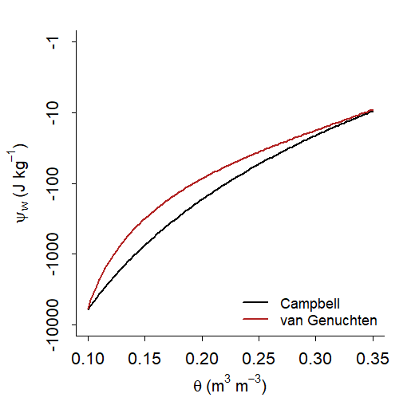

```r
# ------------ Comparison of Campbell and Van Genuchten --------------------- #
Campbell_params <- Campbellparams("Clay loam")
VG_params <- VGparams("Clay loam")

theta <- seq(0.1, 0.35, length.out = 100) # volumetric water content

psiw1 <- with(Campbell_params,
              PsiFromtheta(theta,
                           psie,
                           b,
                           Smax,
                           MPa = FALSE))

psiw2 <- with(VG_params,
              PsiFromthetaVG(theta,
                             Smin,
                             Smax,
                             alpha,
                             n))

# ----------------------------- Plot results ------------------------------ #
par(mar = c(5, 5, 2, 2),
    mfrow = c(1, 1))
plot(theta, log10(-psiw1),
     type = "l",
     lwd = 2,
     ylim = c(log10(1e4), log10(1)),
     yaxt = "n",
     xlab = expression(theta ~ "(m"^3 * " m"^-3 * ")"),
     ylab = expression(psi[w] ~ "(J kg"^-1 * ")"),
     cex.lab = 1.3,
     cex.axis = 1.3)
lines(theta, log10(-psiw2),
      col = "firebrick",
      lwd = 2)
exps <- 0:4
axis(2,
     at = log10(10^exps),
     cex.axis = 1.3,
     labels = paste0("-", 10^exps))
legend("bottomright",
       legend = c("Campbell", "van Genuchten"),
       col = c("black", "firebrick"),
       lwd = 2,
       bty = "n",
       cex = 1.1)
```

The two curves are similar, differing by no more than about a factor of two. They meet in wet soil and again at a water content of about 0.1, where the van Genuchten potential begins to fall steeply as water content approaches its residual value.

Soil texture also strongly influences water retention. Below, we compare clay and sand using the van Genuchten formulation over the same range of water contents.

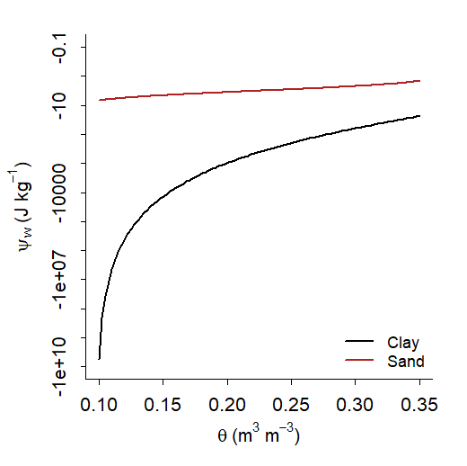

```r
VG_params1 <- VGparams("Clay")
VG_params2 <- VGparams("Sand")

psiw1 <- with(VG_params1,
              PsiFromthetaVG(theta,
                             Smin,
                             Smax,
                             alpha,
                             n))

psiw2 <- with(VG_params2,
              PsiFromthetaVG(theta,
                             Smin,
                             Smax,
                             alpha,
                             n))

# ----------------------------- Plot results ------------------------------ #
par(mar = c(5, 5, 2, 2))
plot(theta, log10(-psiw1),
     type = "l",
     lwd = 2,
     ylim = c(log10(1e10), log10(0.1)),
     yaxt = "n",
     xlab = expression(theta ~ "(m"^3 * " m"^-3 * ")"),
     ylab = expression(psi[w] ~ "(J kg"^-1 * ")"),
     cex.lab = 1.3,
     cex.axis = 1.3)
lines(theta, log10(-psiw2),
      col = "firebrick",
      lwd = 2)
exps <- -1:10
axis(2,
     at = log10(10^exps),
     cex.axis = 1.3,
     labels = paste0("-", 10^exps))
legend("bottomright",
       legend = c("Clay", "Sand"),
       col = c("black", "firebrick"),
       lwd = 2,
       bty = "n",
       cex = 1.1)
```

At the same water content, sand has a much less negative water potential than clay, reflecting its larger pores and weaker retention of water. Clay therefore holds water more tightly, although this does not necessarily mean more water is available to plants.

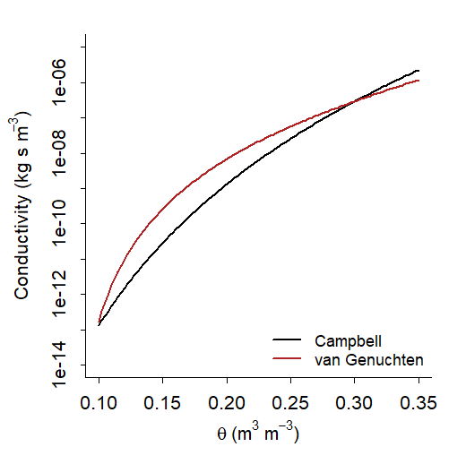

```r
Campbell_params <- Campbellparams("Clay loam")
VG_params <- VGparams("Clay loam")

Ks1 <- with(Campbell_params,
            hydraulicConductivityFromTheta(theta,
                                           b, # Campbell shape parameter
                                           Smax, # volumetric water content at saturation
                                           Ksat)) # saturated hydraulic conductivity

Ks2 <- with(VG_params,
            hydraulicConductivityFromThetaVG(theta,
                                             Smin, # residual water content
                                             Smax, # volumetric water content at saturation
                                             n, # van Genuchten shape parameter
                                             Ko, # conductivity at the matching point
                                             L)) # pore connectivity parameter

# ----------------------------- Plot results ------------------------------ #
par(mar = c(5, 5, 2, 2))
plot(theta, Ks1,
     log = "y",
     type = "l",
     lwd = 2,
     ylim = c(1e-14, 1e-5),
     xlab = expression(theta ~ "(m"^3 * " m"^-3 * ")"),
     ylab = expression("Conductivity (kg s m"^-3 * ")"),
     cex.axis = 1.3,
     cex.lab = 1.3)
lines(theta, Ks2,
      col = "firebrick",
      lwd = 2)
legend("bottomright",
       legend = c("Campbell", "van Genuchten"),
       col = c("black", "firebrick"),
       lwd = 2,
       bty = "n",
       cex = 1.1)
```

Both formulations predict a decline of several orders of magnitude as the soil dries. The van Genuchten curve gives higher conductivities in drier soil and slightly lower ones in the wettest. Together, the water retention and hydraulic conductivity relationships determine how readily water is redistributed through the soil profile.

With these relationships defined, we can now model water movement through the soil. As with the heat model, the soil is divided into vertical layers, with fluxes calculated between them. However, soil water flow is strongly nonlinear because hydraulic conductivity changes by many orders of magnitude with water content. `SoilWaterModel` therefore uses a Newton–Raphson method, iteratively adjusting the solution until the equations governing water movement and storage are satisfied. This requires calculating how fluxes respond to changes in water potential. The Campbell formulation is used because its simple power-law relationships make these calculations efficient.